# Báo cáo phân tích IRT — 1PL / 2PL / 3PL

### Scatter a vs b

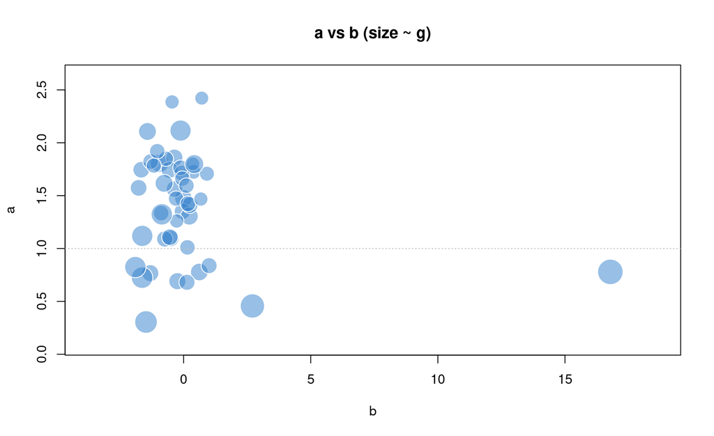

### Wright map (item–person)

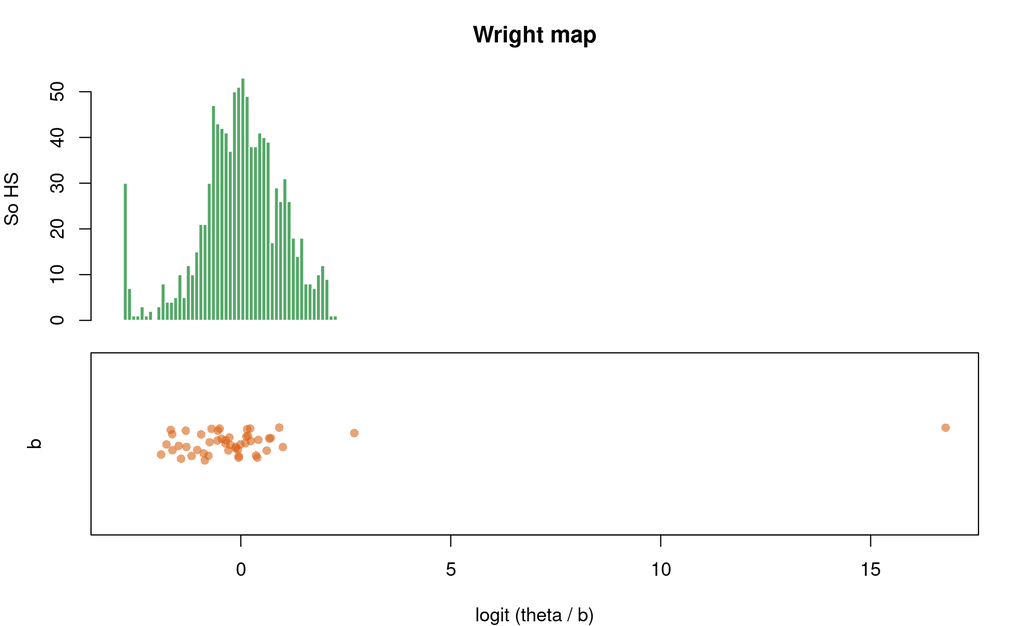

### Item fit: thực nghiệm vs mô hình

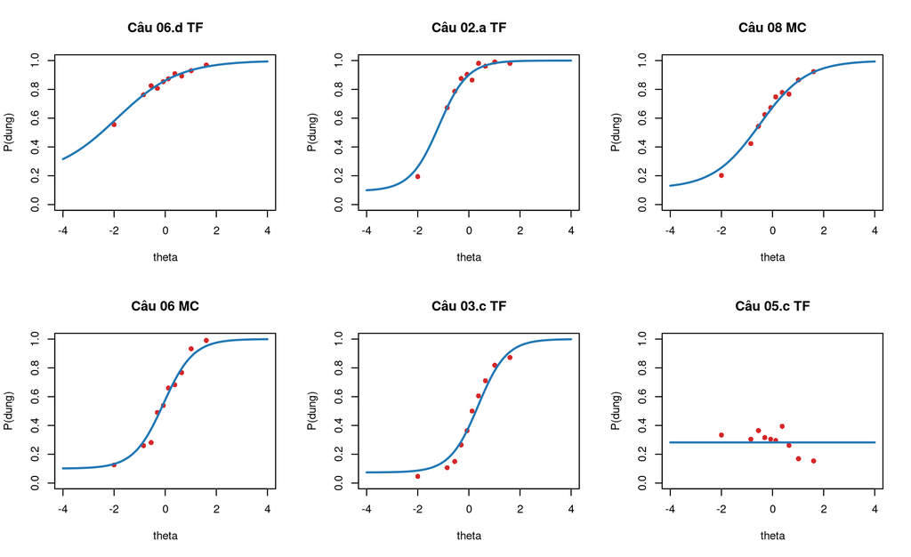

### Phụ thuộc cục bộ Q3

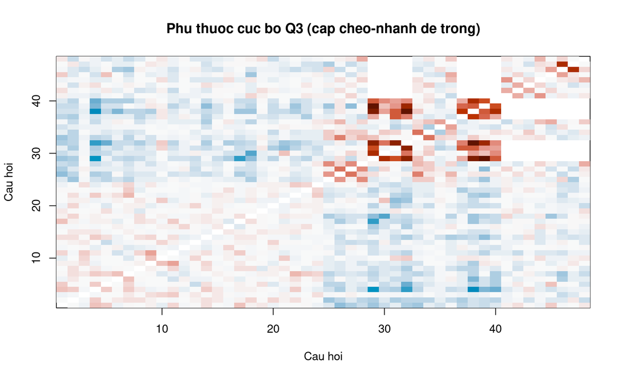

### Person fit

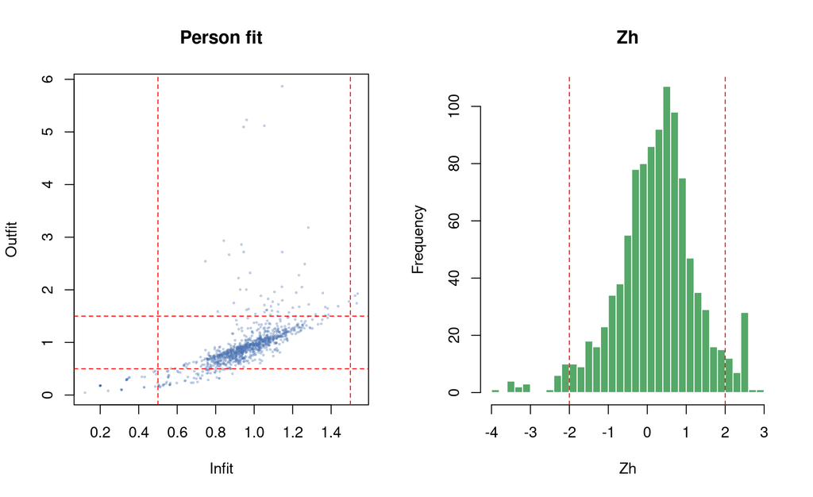

### Item fit (Bock X²)

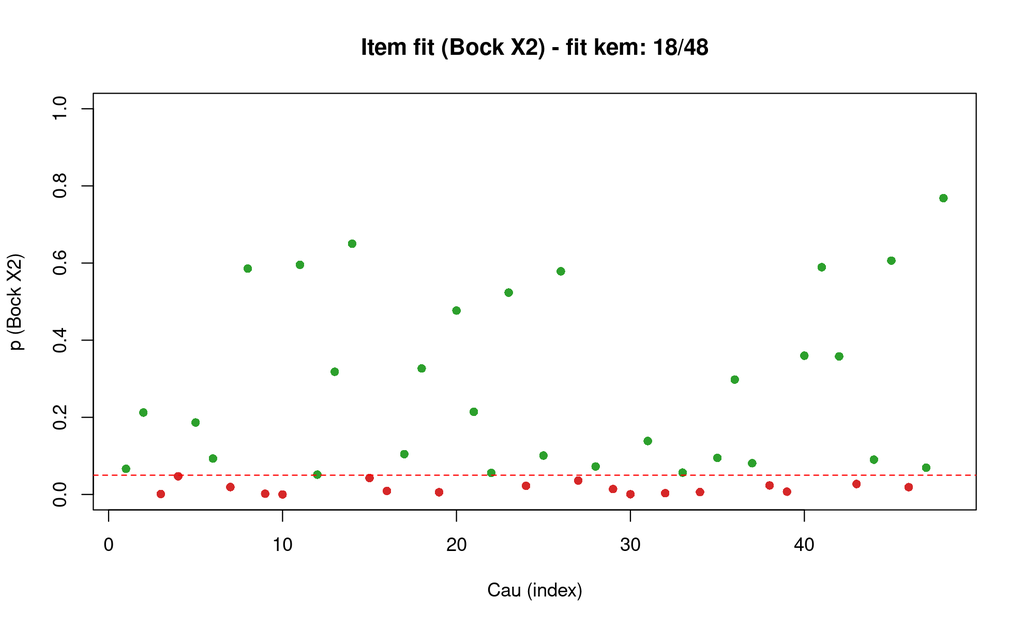

## 3.4 So sánh chéo giữa 1PL/2PL/3PL

### Độ khó b qua các mô hình

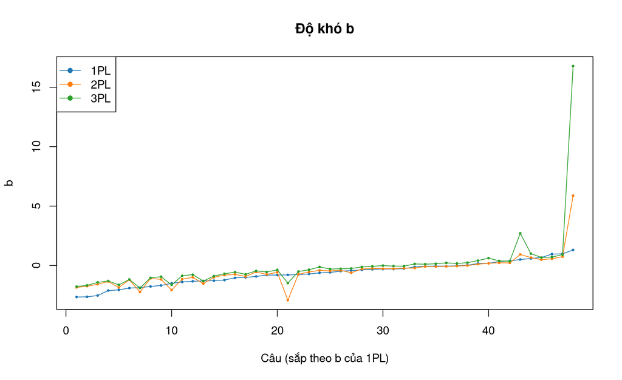

### Năng lực θ giữa các mô hình

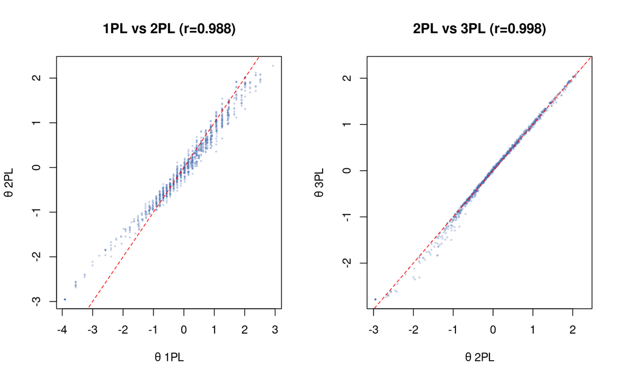

### Scree — kiểm tra đơn chiều

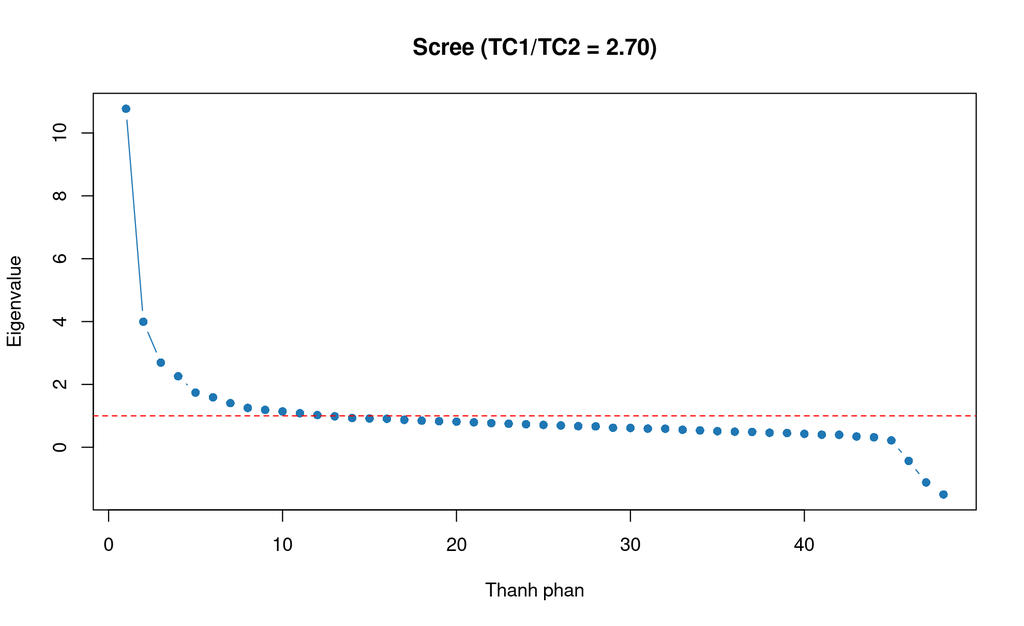

# 4 Phân tích mở rộng — Đề thi thử Tốt nghiệp THPT lần 2 môn Tin học

## CTT và đối chiếu CTT–IRT

- **Cronbach’s α = 0.897 · KR-20 = 0.887** · 48 item · 1037 HS.
- Câu có độ phân biệt CTT yếu (r < 0,20): **4/48** — nên rà soát.

Thống kê item: cỡ mẫu N, số đúng, p, r (CTT) đối chiếu a, b (IRT) — bấm cột để sắp xếp

| Câu | Cỡ mẫu (N) | Số đúng | Độ khó p (CTT) | Phân biệt r (CTT) | b (IRT 2PL) | a (IRT 2PL) |
| --- | --- | --- | --- | --- | --- | --- |
| Câu 01 MC | 1037 | 824 | 0.795 | 0.491 | -1.164 | 1.606 |
| Câu 02 MC | 1037 | 460 | 0.444 | 0.450 | 0.232 | 1.456 |
| Câu 03 MC | 1037 | 615 | 0.593 | 0.289 | -0.608 | 0.670 |
| Câu 04 MC | 1037 | 686 | 0.662 | 0.503 | -0.570 | 1.597 |
| Câu 05 MC | 1037 | 728 | 0.702 | 0.499 | -0.742 | 1.568 |
| Câu 06 MC | 1036 | 594 | 0.573 | 0.493 | -0.244 | 1.547 |
| Câu 07 MC | 1036 | 590 | 0.569 | 0.440 | -0.266 | 1.250 |
| Câu 08 MC | 1037 | 679 | 0.655 | 0.385 | -0.733 | 1.032 |
| Câu 09 MC | 1037 | 924 | 0.891 | 0.478 | -1.844 | 1.573 |
| Câu 10 MC | 1037 | 770 | 0.743 | 0.333 | -1.519 | 0.782 |
| Câu 11 MC | 1036 | 875 | 0.845 | 0.531 | -1.347 | 1.849 |
| Câu 12 MC | 1037 | 775 | 0.747 | 0.468 | -1.000 | 1.428 |
| Câu 13 MC | 1036 | 540 | 0.521 | 0.375 | -0.088 | 0.945 |
| Câu 14 MC | 1036 | 589 | 0.569 | 0.420 | -0.266 | 1.225 |
| Câu 15 MC | 1036 | 721 | 0.696 | 0.407 | -0.924 | 1.073 |
| Câu 16 MC | 1037 | 914 | 0.881 | 0.530 | -1.575 | 1.921 |
| Câu 17 MC | 1036 | 758 | 0.732 | 0.535 | -0.808 | 1.778 |
| Câu 18 MC | 1037 | 553 | 0.533 | 0.295 | -0.212 | 0.656 |
| Câu 19 MC | 1037 | 540 | 0.521 | 0.394 | -0.076 | 1.077 |
| Câu 20 MC | 1036 | 524 | 0.506 | 0.427 | -0.004 | 1.202 |
| Câu 21 MC | 1036 | 409 | 0.395 | 0.289 | 0.669 | 0.727 |
| Câu 22 MC | 1036 | 491 | 0.474 | 0.279 | 0.182 | 0.684 |
| Câu 23 MC | 1036 | 670 | 0.647 | 0.482 | -0.547 | 1.432 |
| Câu 24 MC | 1037 | 923 | 0.890 | 0.491 | -1.739 | 1.732 |
| Câu 01.a TF | 1036 | 708 | 0.683 | 0.574 | -0.540 | 2.321 |
| Câu 01.b TF | 1036 | 835 | 0.806 | 0.547 | -1.083 | 2.002 |
| Câu 01.c TF | 1036 | 645 | 0.623 | 0.474 | -0.452 | 1.417 |
| Câu 01.d TF | 1036 | 766 | 0.739 | 0.471 | -0.990 | 1.360 |
| Câu 02.a TF | 1036 | 851 | 0.821 | 0.540 | -1.203 | 1.874 |
| Câu 02.b TF | 1036 | 625 | 0.603 | 0.452 | -0.408 | 1.256 |
| Câu 02.c TF | 1036 | 495 | 0.478 | 0.412 | 0.112 | 1.270 |
| Câu 02.d TF | 1036 | 687 | 0.663 | 0.396 | -0.749 | 1.079 |
| Câu 03.a TF | 424 | 220 | 0.519 | 0.579 | -0.294 | 1.678 |
| Câu 03.b TF | 424 | 121 | 0.285 | 0.433 | 0.741 | 1.288 |
| Câu 03.c TF | 424 | 163 | 0.384 | 0.541 | 0.217 | 1.677 |
| Câu 03.d TF | 424 | 212 | 0.500 | 0.555 | -0.225 | 1.593 |
| Câu 04.a TF | 424 | 123 | 0.290 | 0.507 | 0.574 | 1.833 |
| Câu 04.b TF | 424 | 194 | 0.458 | 0.503 | -0.052 | 1.334 |
| Câu 04.c TF | 424 | 197 | 0.465 | 0.531 | -0.086 | 1.498 |
| Câu 04.d TF | 424 | 142 | 0.335 | 0.469 | 0.488 | 1.327 |
| Câu 05.a TF | 617 | 273 | 0.442 | 0.084 | 0.928 | 0.320 |
| Câu 05.b TF | 617 | 505 | 0.818 | 0.210 | -2.062 | 0.714 |
| Câu 05.c TF | 617 | 176 | 0.285 | -0.111 | 5.877 | 0.162 |
| Câu 05.d TF | 617 | 436 | 0.707 | 0.051 | -2.915 | 0.286 |
| Câu 06.a TF | 617 | 544 | 0.882 | 0.242 | -1.850 | 1.123 |
| Câu 06.b TF | 617 | 416 | 0.674 | 0.438 | -0.405 | 1.743 |
| Câu 06.c TF | 617 | 495 | 0.802 | 0.299 | -1.144 | 1.260 |
| Câu 06.d TF | 617 | 532 | 0.862 | 0.199 | -2.229 | 0.820 |

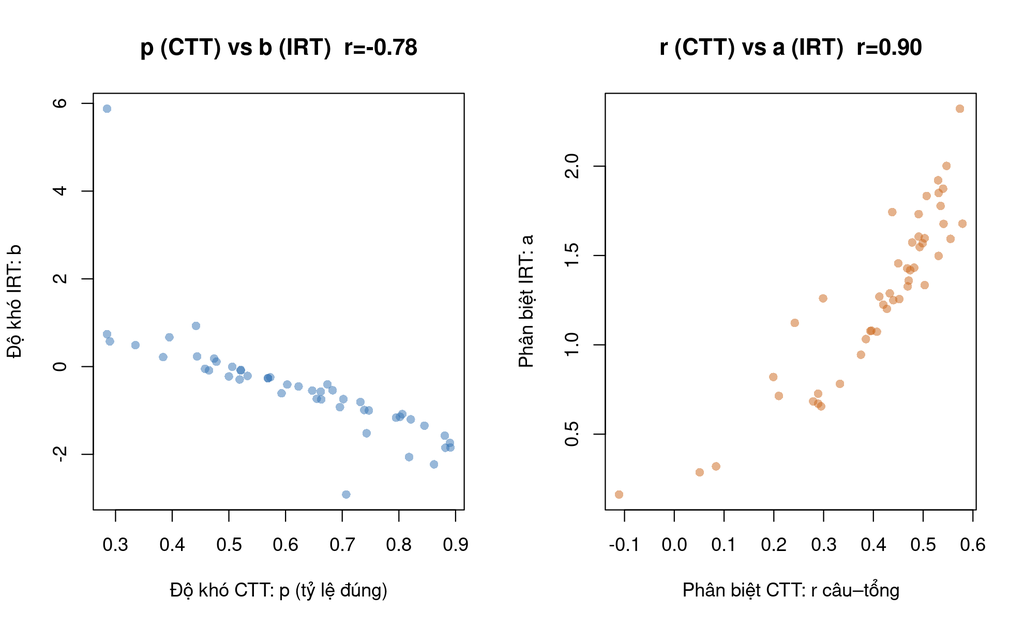

Đối chiếu CTT–IRT theo các tiêu chí chính (theo tài liệu nền, mục 2.2)

| Tiêu chí | CTT | IRT |
| --- | --- | --- |
| Đơn vị phân tích | Cấp độ đề (điểm tổng) | Cấp độ câu hỏi |
| Đại lượng năng lực | Điểm thô, phụ thuộc đề | θ trên thang chung, độc lập đề |
| Tham số câu hỏi | Độ khó = tỷ lệ đúng; phân biệt = r câu–tổng | a, b, c cùng thang với θ |
| Tính bất biến | Không (đổi theo nhóm/đề) | Có (khi mô hình phù hợp) |
| Sai số đo | Một giá trị chung mọi HS | Thay đổi theo θ (hàm thông tin) |
| Độ tin cậy | Qua ‘hai đề tương đương’ | Hàm thông tin I(θ) |
| Dự báo ứng đáp | Không trả lời ‘P đúng câu này?’ | Trả lời trực tiếp qua P(θ) |

## Các cách ước lượng tham số IRT

### Ước lượng năng lực θ: ML · WLE · MAP · EAP

Bốn cách ước lượng θ trên cùng mô hình 2PL (29 HS điểm biên)

| Bộ ước lượng | Loại | SD(θ) — HS không biên | Điểm biên (đúng/sai toàn bộ) |
| --- | --- | --- | --- |
| ML | Tần suất | 1.101 | ±∞ → bị chặn (29 HS) |
| WLE | Tần suất | 0.978 | ±∞ → bị chặn (29 HS) |
| MAP | Bayes (mode) | 0.833 | Hữu hạn |
| EAP | Bayes (kỳ vọng) | 0.863 | Hữu hạn |

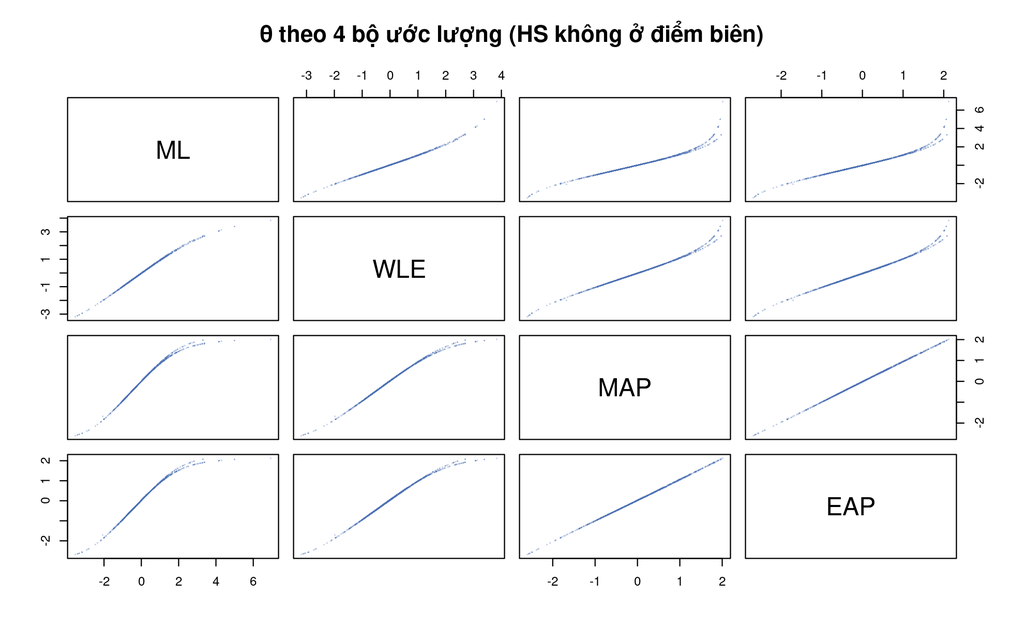

> **Cách đọc:** bốn cách tương quan rất cao nhưng **không trùng**. ML/WLE (tần suất) không có tiên nghiệm nên **không định được** HS đúng/sai toàn bộ (điểm biên — mục 1.6); MAP/EAP (Bayes) thêm tiên nghiệm N(0,1) nên ổn định ở hai cực nhưng **co rút** về 0 (SD nhỏ hơn — mục 3.7).

### Cùng một đường cong, nhiều cách tham số hoá

Cùng ICC, 3 metric: IRT (a,b) · slope–intercept (a,d) · vòm chuẩn (a*)

| Câu | a | b | d = −a·b (slope–intercept) | a* = a/1,702 (vòm chuẩn) |
| --- | --- | --- | --- | --- |
| Câu 05.d TF | 0.286 | -2.915 | 0.835 | 0.168 |
| Câu 02.a TF | 1.874 | -1.203 | 2.254 | 1.101 |
| Câu 08 MC | 1.032 | -0.733 | 0.757 | 0.606 |
| Câu 07 MC | 1.250 | -0.266 | 0.333 | 0.734 |
| Câu 02.c TF | 1.270 | 0.112 | -0.142 | 0.746 |
| Câu 05.c TF | 0.162 | 5.877 | -0.954 | 0.095 |

> Logit: ln[P/(1−P)] = a(θ−b) = a·θ + d với d = −a·b. Logistic ↔︎ vòm chuẩn nối qua hằng số D≈1,702 (Haley 1952): nhân a với 1/1,702 để đổi metric. **Cùng một đường cong, chỉ khác cách viết** (mục 3.4).

### Thuật toán ước lượng: EM vs MH-RM

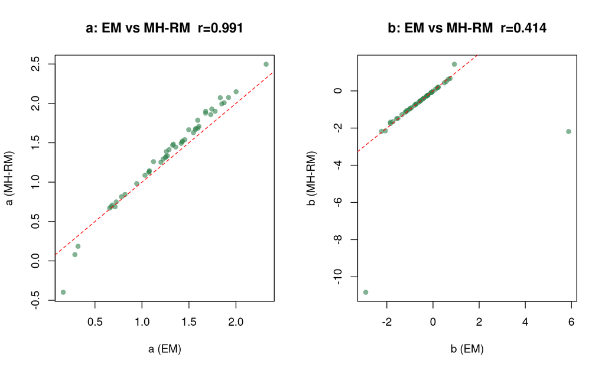

## Tính bất biến & DIF — chia lại mẫu

### Tách ngẫu nhiên 2 nhóm → bất biến tham số

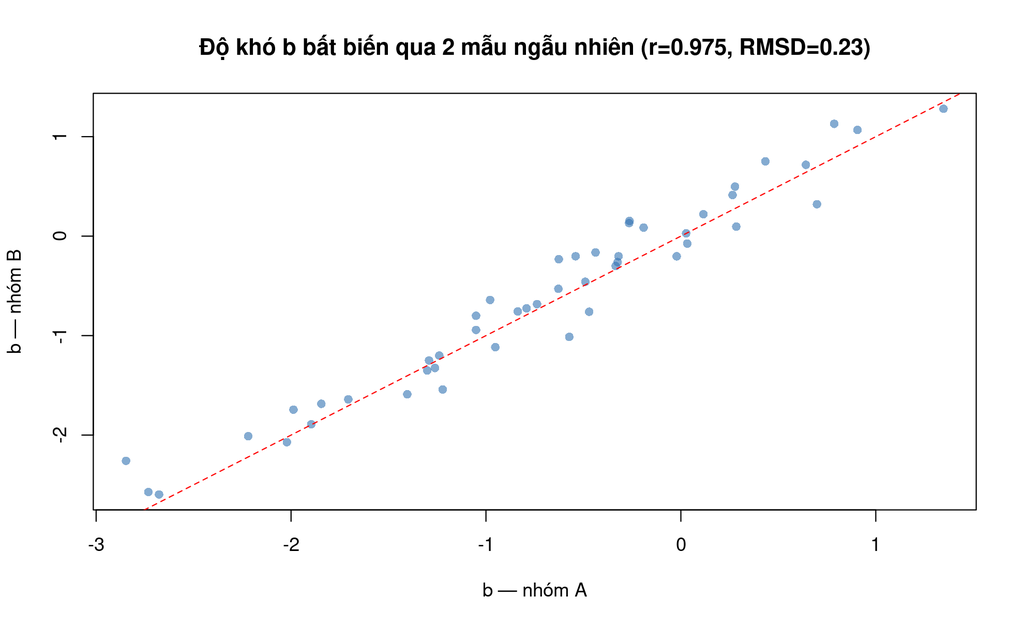

> Hai nhóm HS độc lập cho **cùng** độ khó câu (bám đường chéo) ⇒ tham số câu **không phụ thuộc mẫu** (sample-free). Đây là ‘hòn đá tảng’ (mục 2.3) mà CTT không có.

### Tách theo năng lực → CTT đổi theo nhóm, IRT giữ nguyên

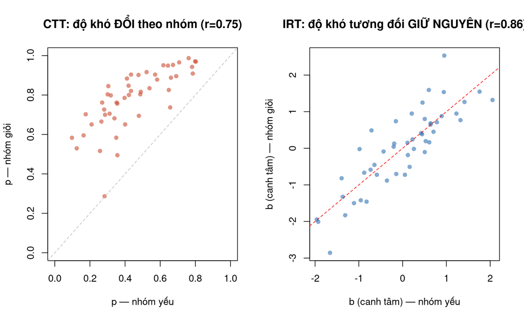

> Đây là ‘Hình 4 — hòn đá tảng’ tái hiện trên dữ liệu thật: tỷ lệ đúng (độ khó CTT) **co dãn theo năng lực nhóm** (nhóm giỏi thấy mọi câu dễ hơn), còn **thứ tự & khoảng cách độ khó IRT được bảo toàn** sau canh tâm. Vị trí tuyệt đối b lệch một hằng số giữa 2 nhóm ⇒ cần *so bằng/anchor* để gộp thang (mục 3.10).

### Chênh độ khó giữa 2 mẫu ngẫu nhiên (kiểm tra ổn định)

8 câu chênh độ khó nhiều nhất giữa 2 mẫu ngẫu nhiên

| Câu | b_A | b_B | Δb |
| --- | --- | --- | --- |
| Câu 16 MC | -2.85 | -2.26 | -0.59 |
| Câu 05.d TF | -0.57 | -1.01 | 0.44 |
| Câu 13 MC | -0.26 | 0.15 | -0.42 |
| Câu 04.c TF | -0.27 | 0.13 | -0.40 |
| Câu 03 MC | -0.63 | -0.23 | -0.39 |
| Câu 05.a TF | 0.70 | 0.32 | 0.38 |
| Câu 04.a TF | 0.79 | 1.13 | -0.34 |
| Câu 03.a TF | -0.54 | -0.20 | -0.34 |

> Đây là 2 mẫu **ngẫu nhiên** nên Δb đo **sai số lấy mẫu**, KHÔNG phải DIF. Số câu |Δb| > 0,5 logit: **1/48**; Δb nhỏ ⇒ tham số câu **ổn định qua mẫu**, củng cố tính bất biến. (DIF thật — chênh theo nhóm có ý nghĩa — xem mục dưới.)

### DIF theo nhánh: KHMT vs Tin ứng dụng (trên câu neo chung)

- Nhóm: **KHMT 419 HS** · **Tin ứng dụng 612 HS** · kiểm định **32 câu neo**.
- Câu neo có **DIF** (p hiệu chỉnh BH < 0,05): **6/32**.

DIF câu neo giữa 2 nhánh — X² Wald (df=2: a & b), sắp theo p; bấm cột để sắp xếp

| Câu | X² (a&b) | df | p | p hiệu chỉnh | DIF |
| --- | --- | --- | --- | --- | --- |
| Câu 10 MC | 17.53 | 2 | 0.000156 | 0.0050 | ⚠ có |
| Câu 02 MC | 14.29 | 2 | 0.000787 | 0.0126 | ⚠ có |
| Câu 09 MC | 12.35 | 2 | 0.002080 | 0.0187 | ⚠ có |
| Câu 01.d TF | 12.12 | 2 | 0.002330 | 0.0187 | ⚠ có |
| Câu 01 MC | 10.10 | 2 | 0.006420 | 0.0365 | ⚠ có |
| Câu 16 MC | 9.97 | 2 | 0.006850 | 0.0365 | ⚠ có |
| Câu 04 MC | 7.43 | 2 | 0.024400 | 0.1110 |  |
| Câu 02.b TF | 6.34 | 2 | 0.042000 | 0.1680 |  |
| Câu 08 MC | 5.60 | 2 | 0.060700 | 0.2160 |  |
| Câu 21 MC | 4.92 | 2 | 0.085600 | 0.2550 |  |
| Câu 02.c TF | 4.87 | 2 | 0.087700 | 0.2550 |  |
| Câu 15 MC | 4.48 | 2 | 0.107000 | 0.2680 |  |
| Câu 14 MC | 4.35 | 2 | 0.114000 | 0.2680 |  |
| Câu 19 MC | 4.29 | 2 | 0.117000 | 0.2680 |  |
| Câu 18 MC | 4.00 | 2 | 0.135000 | 0.2880 |  |
| Câu 02.a TF | 3.80 | 2 | 0.150000 | 0.3000 |  |
| Câu 22 MC | 3.33 | 2 | 0.189000 | 0.3560 |  |
| Câu 02.d TF | 3.10 | 2 | 0.213000 | 0.3670 |  |
| Câu 17 MC | 3.05 | 2 | 0.218000 | 0.3670 |  |
| Câu 20 MC | 2.81 | 2 | 0.246000 | 0.3930 |  |
| Câu 01.c TF | 2.41 | 2 | 0.300000 | 0.4560 |  |
| Câu 03 MC | 2.32 | 2 | 0.313000 | 0.4560 |  |
| Câu 11 MC | 2.15 | 2 | 0.341000 | 0.4700 |  |
| Câu 13 MC | 2.09 | 2 | 0.352000 | 0.4700 |  |
| Câu 01.a TF | 1.64 | 2 | 0.441000 | 0.5640 |  |
| Câu 12 MC | 1.52 | 2 | 0.467000 | 0.5740 |  |
| Câu 05 MC | 1.45 | 2 | 0.486000 | 0.5750 |  |
| Câu 07 MC | 1.30 | 2 | 0.523000 | 0.5980 |  |
| Câu 24 MC | 0.56 | 2 | 0.757000 | 0.8360 |  |
| Câu 23 MC | 0.13 | 2 | 0.935000 | 0.9960 |  |
| Câu 01.b TF | 0.05 | 2 | 0.973000 | 0.9960 |  |
| Câu 06 MC | 0.01 | 2 | 0.996000 | 0.9960 |  |

> **Cách đọc:** học sinh chọn KHMT và chọn Tin ứng dụng có nền tảng khác nhau. Câu neo **DIF** nghĩa là ở **cùng năng lực θ**, hai nhóm có xác suất đúng khác nhau ⇒ **câu thiên lệch theo nhóm** (mục 2.2, 3.9). Hệ quả: khi muốn **so θ trực tiếp giữa hai nhánh**, chỉ nên neo thang bằng các câu **không** DIF; câu DIF nên rà soát nội dung (có thiên về một phân môn không).

## Chẩn đoán bổ sung

### Độ phù hợp tuyệt đối (M2, RMSEA, SRMSR, CFI/TLI)

Độ phù hợp tuyệt đối từng mô hình

| Model | M2 | df | p | RMSEA | SRMSR | CFI | TLI |
| --- | --- | --- | --- | --- | --- | --- | --- |
| 1PL | 4946.5 | 1127 | 0 | 0.057 | 0.379 | 0.898 | 0.898 |
| 2PL | 4131.2 | 1080 | 0 | 0.052 | 0.367 | 0.919 | 0.915 |
| 3PL | 3218.6 | 1032 | 0 | 0.045 | 0.363 | 0.942 | 0.936 |

> **Ngưỡng:** RMSEA < 0,06 · SRMSR < 0,08 · CFI/TLI > 0,95 là phù hợp tốt. AIC/BIC chỉ chọn mô hình *ít tệ hơn*; M2 cho biết mô hình tốt nhất có **đủ tốt tuyệt đối** không. RMSEA/SRMSR cao ⇒ vi phạm giả định (thường do phụ thuộc cục bộ câu chùm) ⇒ tính bất biến lung lay (mục 3.8).

### Item infit/outfit MNSQ (mô hình 1PL/Rasch)

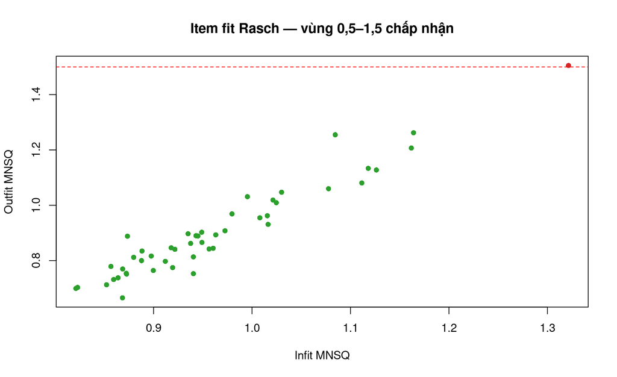

- Câu lệch fit (MNSQ ngoài 0,5–1,5): **1/48**.

Câu lệch fit Rasch

| Câu | infit | outfit |
| --- | --- | --- |
| Câu 05.c TF | 1.32 | 1.51 |

> infit/outfit MNSQ là chỉ số fit chuẩn của Rasch (mục 1.7, 3.8): quanh 1 là khớp, >1,5 là nhiễu (câu đo không nhất quán với năng lực).

### Độ tin cậy số

- Marginal reliability (IRT) = **0.915** · Empirical reliability = **0.901** · Cronbach’s α (CTT) = **0.897**.

> IRT thay ‘độ tin cậy một số’ của CTT bằng độ tin cậy biến thiên theo θ (đã vẽ ở ρ(θ)); marginal_rxx tổng hợp lại thành một số để đối chiếu với α.

### Kiểm định đơn chiều

- (Trên 32 câu neo chung, dữ liệu đầy đủ) Tỷ lệ eigenvalue λ1/λ2 = **4.63** — càng lớn càng đơn chiều.
- Parallel analysis (tetrachoric) gợi ý **8** nhân tố.

> Tính trên **câu neo chung** vì hai nhánh elective không có HS làm chung ⇒ không tính được tương quan trực tiếp (chúng chỉ **liên kết qua mô hình IRT**). Nếu >1 nhân tố, phần lớn do **phụ thuộc cục bộ câu chùm** (đọc cùng LD bên dưới), không hẳn đa chiều năng lực.

### Phụ thuộc cục bộ: cặp |Q3| lớn

10 cặp câu phụ thuộc cục bộ mạnh nhất (chỉ cặp đủ HS làm chung)

| Câu i | Câu j | Q3 |
| --- | --- | --- |
| Câu 03.a TF | Câu 04.c TF | 0.435 |
| Câu 03.d TF | Câu 04.b TF | 0.420 |
| Câu 03.a TF | Câu 04.b TF | 0.390 |
| Câu 03.a TF | Câu 03.d TF | 0.370 |
| Câu 03.c TF | Câu 03.d TF | 0.366 |
| Câu 06.b TF | Câu 06.c TF | 0.352 |
| Câu 03.d TF | Câu 04.c TF | 0.349 |
| Câu 04.b TF | Câu 04.d TF | 0.334 |
| Câu 03.a TF | Câu 03.b TF | 0.332 |
| Câu 04.a TF | Câu 04.b TF | 0.332 |

### Quy đổi θ ↔︎ điểm thực (đường đặc trưng đề)

θ → điểm thực kỳ vọng (đề 48 item)

| θ | Điểm thực kỳ vọng τ(θ) | % trên tổng |
| --- | --- | --- |
| -3 | 3.9 | 8.2 |
| -2 | 8.8 | 18.3 |
| -1 | 18.7 | 39.1 |
| 0 | 31.1 | 64.8 |
| 1 | 40.0 | 83.3 |
| 2 | 44.2 | 92.1 |
| 3 | 45.9 | 95.6 |

> Cầu nối thang θ trừu tượng ↔︎ ‘số câu đúng’ quen thuộc (mục 3.6): biết θ, dự báo được HS làm đúng khoảng bao nhiêu item; đảo ngược cho ánh xạ điểm thô → θ.

# 5 Đề thi thử Tốt nghiệp THPT môn Tin học - Lần 1 (2025 - 2026)

- Đề thi thử **môn Tin học** trên nền tảng **OLM** · **2543 thí sinh** · **48 item**

## So sánh mô hình

Chỉ số fit theo mô hình

| Model | npars | logLik | AIC | BIC | converged |
| --- | --- | --- | --- | --- | --- |
| 1PL | 49 | -51731.3 | 103560.6 | 103846.8 | TRUE |
| 2PL | 96 | -51024.3 | 102240.6 | 102801.3 | TRUE |
| 3PL | 144 | -51130.6 | 102549.3 | 103390.4 | TRUE |

LRT 1PL→2PL: X²=1414.0, df=47, p=2.2e-265 | 2PL→3PL: X²=-212.7, df=48, p=1

**Mô hình tốt nhất theo AIC: 2PL** (BIC: 2PL)

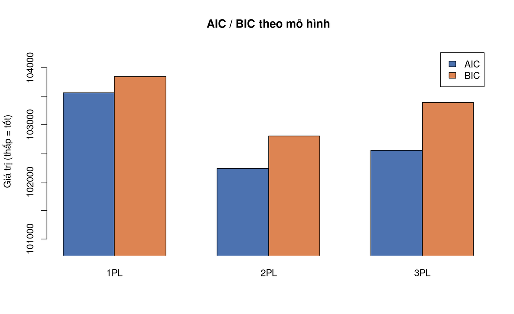

## 5.1 Mô hình 1PL

### Phân bố tham số item

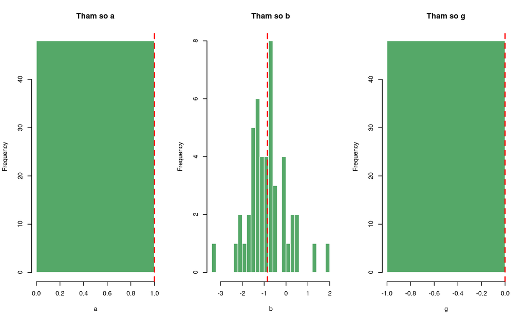

### Bảng tham số item (theo Câu)

Tham số item 1PL — cỡ mẫu N, số đúng, a, b, g (bấm cột để sắp xếp)

| Câu | Cỡ mẫu (N) | Số đúng | a | b | g |
| --- | --- | --- | --- | --- | --- |
| Câu 01 MC | 2530 | 1584 | 1 | -0.626 | 0 |
| Câu 02 MC | 2531 | 1626 | 1 | -0.718 | 0 |
| Câu 03 MC | 2529 | 1871 | 1 | -1.311 | 0 |
| Câu 04 MC | 2532 | 2075 | 1 | -1.913 | 0 |
| Câu 05 MC | 2532 | 2348 | 1 | -3.235 | 0 |
| Câu 06 MC | 2531 | 2028 | 1 | -1.763 | 0 |
| Câu 07 MC | 2530 | 1697 | 1 | -0.881 | 0 |
| Câu 08 MC | 2530 | 2168 | 1 | -2.269 | 0 |
| Câu 09 MC | 2527 | 2110 | 1 | -2.049 | 0 |
| Câu 10 MC | 2526 | 1642 | 1 | -0.758 | 0 |
| Câu 11 MC | 2527 | 1896 | 1 | -1.381 | 0 |
| Câu 12 MC | 2527 | 1926 | 1 | -1.464 | 0 |
| Câu 13 MC | 2526 | 1744 | 1 | -0.996 | 0 |
| Câu 14 MC | 2526 | 1641 | 1 | -0.756 | 0 |
| Câu 15 MC | 2528 | 1227 | 1 | 0.122 | 0 |
| Câu 16 MC | 2526 | 1523 | 1 | -0.496 | 0 |
| Câu 17 MC | 2526 | 1377 | 1 | -0.188 | 0 |
| Câu 18 MC | 2525 | 1724 | 1 | -0.950 | 0 |
| Câu 19 MC | 2526 | 1558 | 1 | -0.572 | 0 |
| Câu 20 MC | 2526 | 1300 | 1 | -0.029 | 0 |
| Câu 21 MC | 2527 | 1828 | 1 | -1.202 | 0 |
| Câu 22 MC | 2525 | 1049 | 1 | 0.489 | 0 |
| Câu 23 MC | 2527 | 1944 | 1 | -1.516 | 0 |
| Câu 24 MC | 2526 | 1974 | 1 | -1.607 | 0 |
| Câu 01.a TF | 2525 | 2137 | 1 | -2.160 | 0 |
| Câu 01.b TF | 2525 | 1827 | 1 | -1.205 | 0 |
| Câu 01.c TF | 2525 | 1324 | 1 | -0.081 | 0 |
| Câu 01.d TF | 2525 | 1842 | 1 | -1.243 | 0 |
| Câu 02.a TF | 2526 | 1011 | 1 | 0.569 | 0 |
| Câu 02.b TF | 2526 | 1631 | 1 | -0.735 | 0 |
| Câu 02.c TF | 2526 | 1911 | 1 | -1.426 | 0 |
| Câu 02.d TF | 2526 | 1586 | 1 | -0.635 | 0 |
| Câu 03.a TF | 1307 | 902 | 1 | -1.151 | 0 |
| Câu 03.b TF | 1307 | 806 | 1 | -0.699 | 0 |
| Câu 03.c TF | 1307 | 882 | 1 | -1.053 | 0 |
| Câu 03.d TF | 1307 | 893 | 1 | -1.107 | 0 |
| Câu 04.a TF | 1297 | 548 | 1 | 0.392 | 0 |
| Câu 04.b TF | 1297 | 797 | 1 | -0.675 | 0 |
| Câu 04.c TF | 1297 | 580 | 1 | 0.257 | 0 |
| Câu 04.d TF | 1297 | 677 | 1 | -0.152 | 0 |
| Câu 05.a TF | 1296 | 357 | 1 | 1.267 | 0 |
| Câu 05.b TF | 1296 | 888 | 1 | -0.877 | 0 |
| Câu 05.c TF | 1296 | 1025 | 1 | -1.532 | 0 |
| Câu 05.d TF | 1296 | 961 | 1 | -1.207 | 0 |
| Câu 06.a TF | 1297 | 238 | 1 | 1.897 | 0 |
| Câu 06.b TF | 1297 | 823 | 1 | -0.600 | 0 |
| Câu 06.c TF | 1297 | 1030 | 1 | -1.552 | 0 |
| Câu 06.d TF | 1297 | 921 | 1 | -1.016 | 0 |

### ICC — Đường cong đặc trưng câu hỏi

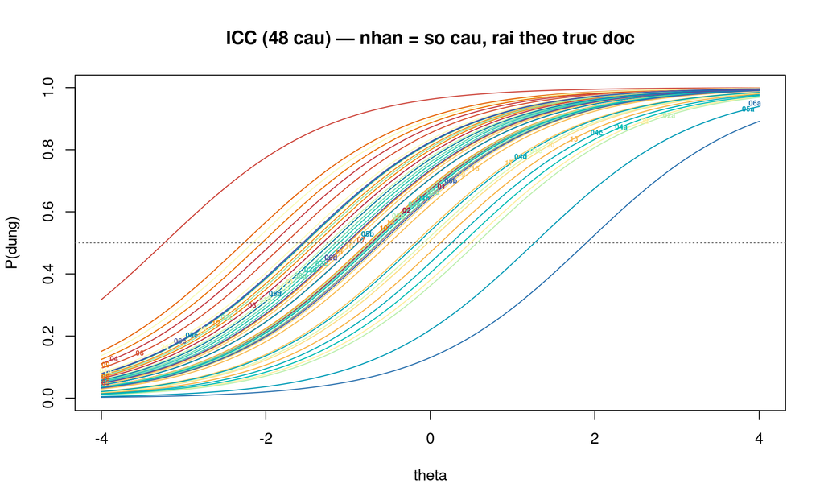

### IIC — Thông tin từng câu

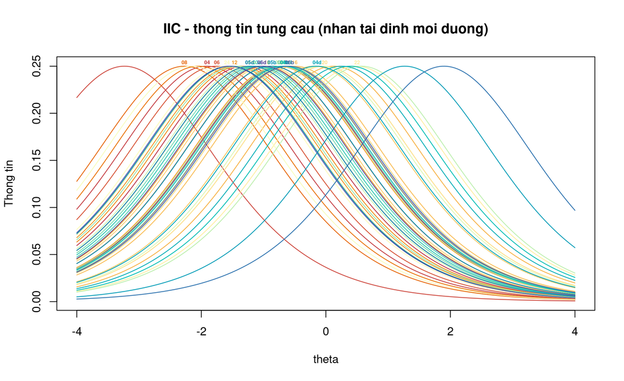

### TIF & SE(θ)

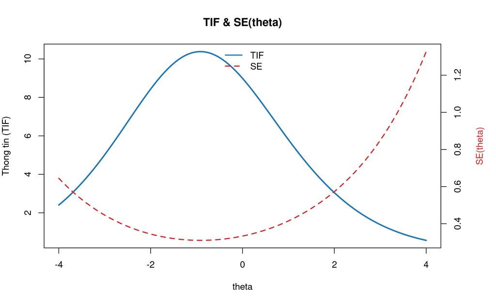

### TCC — Đường cong đặc trưng bài test

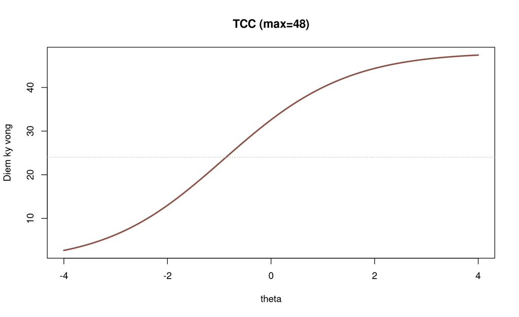

### Độ tin cậy theo năng lực

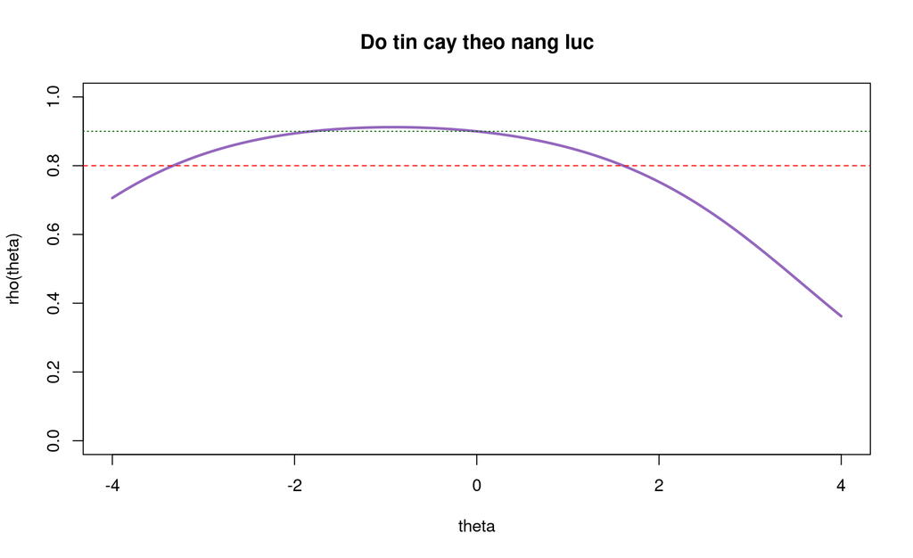

### Scatter a vs b

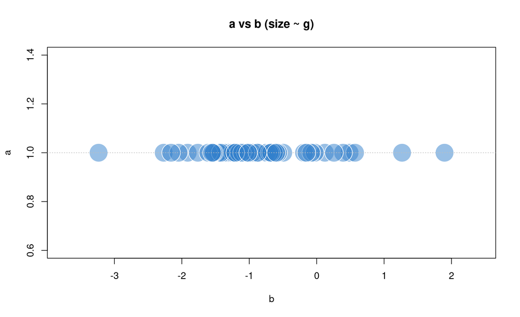

### Wright map (item–person)

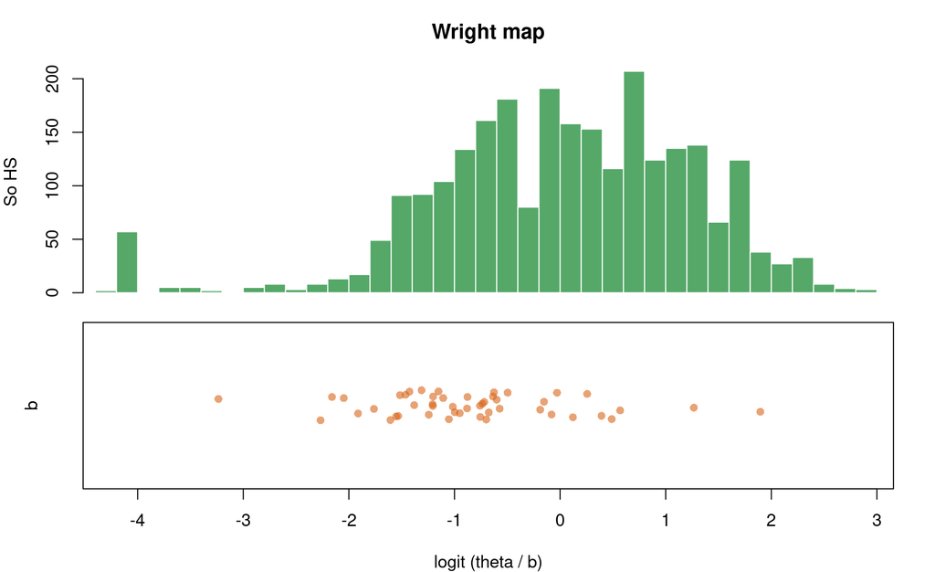

### Item fit: thực nghiệm vs mô hình

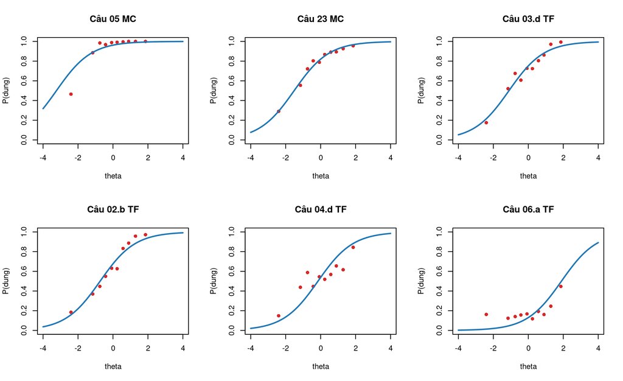

### Phụ thuộc cục bộ Q3

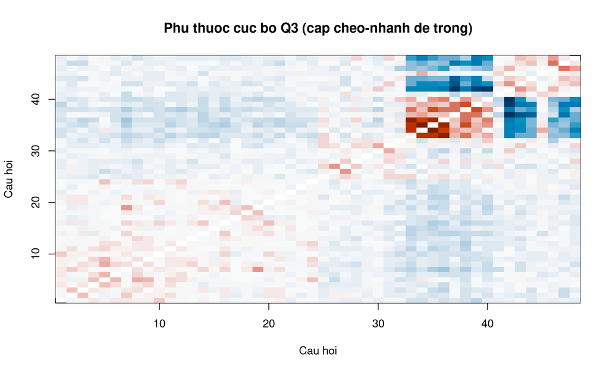

### Person fit

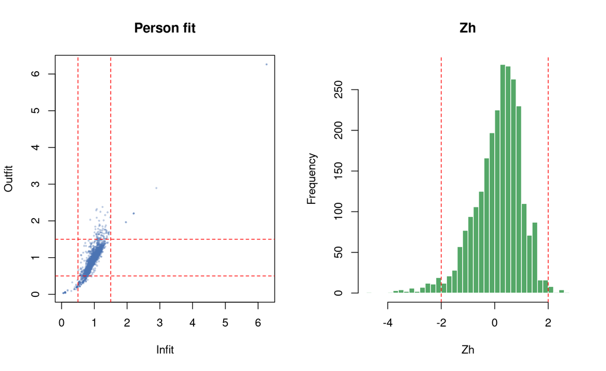

### Item fit (Bock X²)

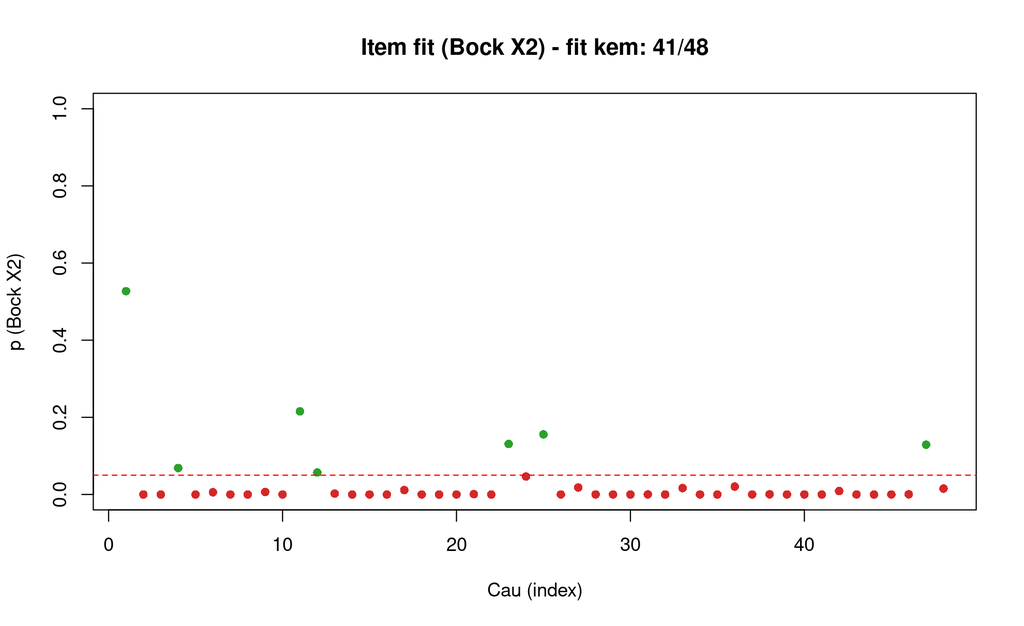

## 5.2 Mô hình 2PL

### Phân bố tham số item

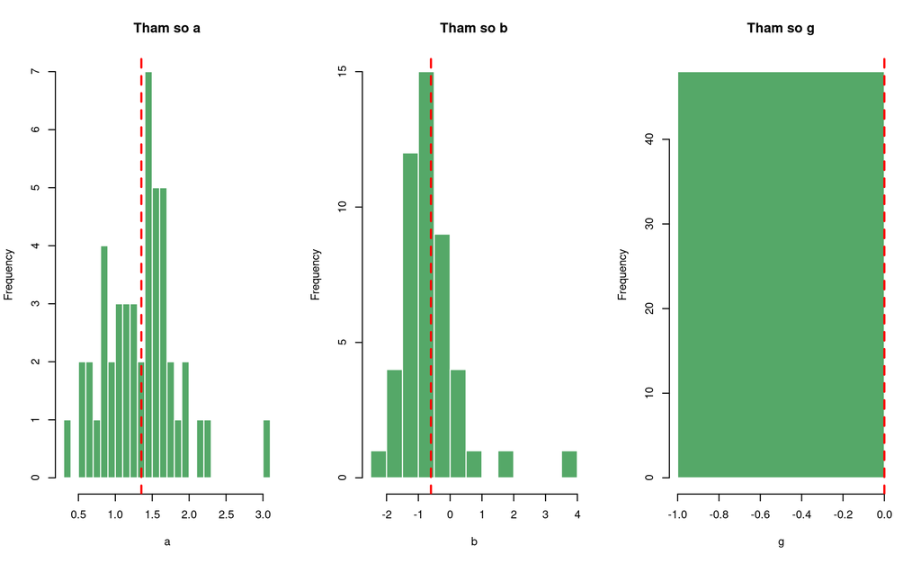

### Bảng tham số item (theo Câu)

Tham số item 2PL — cỡ mẫu N, số đúng, a, b, g (bấm cột để sắp xếp)

| Câu | Cỡ mẫu (N) | Số đúng | a | b | g |
| --- | --- | --- | --- | --- | --- |
| Câu 01 MC | 2530 | 1584 | 1.800 | -0.414 | 0 |
| Câu 02 MC | 2531 | 1626 | 1.153 | -0.618 | 0 |
| Câu 03 MC | 2529 | 1871 | 1.626 | -0.895 | 0 |
| Câu 04 MC | 2532 | 2075 | 1.390 | -1.421 | 0 |
| Câu 05 MC | 2532 | 2348 | 3.027 | -1.641 | 0 |
| Câu 06 MC | 2531 | 2028 | 1.267 | -1.391 | 0 |
| Câu 07 MC | 2530 | 1697 | 2.260 | -0.522 | 0 |
| Câu 08 MC | 2530 | 2168 | 2.179 | -1.318 | 0 |
| Câu 09 MC | 2527 | 2110 | 1.714 | -1.343 | 0 |
| Câu 10 MC | 2526 | 1642 | 1.647 | -0.522 | 0 |
| Câu 11 MC | 2527 | 1896 | 1.531 | -0.974 | 0 |
| Câu 12 MC | 2527 | 1926 | 1.478 | -1.053 | 0 |
| Câu 13 MC | 2526 | 1744 | 1.523 | -0.711 | 0 |
| Câu 14 MC | 2526 | 1641 | 1.664 | -0.517 | 0 |
| Câu 15 MC | 2528 | 1227 | 0.893 | 0.094 | 0 |
| Câu 16 MC | 2526 | 1523 | 1.944 | -0.319 | 0 |
| Câu 17 MC | 2526 | 1377 | 1.017 | -0.195 | 0 |
| Câu 18 MC | 2525 | 1724 | 1.750 | -0.629 | 0 |
| Câu 19 MC | 2526 | 1558 | 1.594 | -0.404 | 0 |
| Câu 20 MC | 2526 | 1300 | 1.676 | -0.030 | 0 |
| Câu 21 MC | 2527 | 1828 | 1.464 | -0.874 | 0 |
| Câu 22 MC | 2525 | 1049 | 0.864 | 0.474 | 0 |
| Câu 23 MC | 2527 | 1944 | 1.236 | -1.221 | 0 |
| Câu 24 MC | 2526 | 1974 | 1.534 | -1.128 | 0 |
| Câu 01.a TF | 2525 | 2137 | 1.250 | -1.713 | 0 |
| Câu 01.b TF | 2525 | 1827 | 1.159 | -1.018 | 0 |
| Câu 01.c TF | 2525 | 1324 | 1.082 | -0.092 | 0 |
| Câu 01.d TF | 2525 | 1842 | 1.034 | -1.140 | 0 |
| Câu 02.a TF | 2526 | 1011 | 0.753 | 0.618 | 0 |
| Câu 02.b TF | 2526 | 1631 | 1.435 | -0.548 | 0 |
| Câu 02.c TF | 2526 | 1911 | 1.000 | -1.336 | 0 |
| Câu 02.d TF | 2526 | 1586 | 0.512 | -1.072 | 0 |
| Câu 03.a TF | 1307 | 902 | 1.486 | -0.830 | 0 |
| Câu 03.b TF | 1307 | 806 | 1.962 | -0.449 | 0 |
| Câu 03.c TF | 1307 | 882 | 1.671 | -0.717 | 0 |
| Câu 03.d TF | 1307 | 893 | 1.384 | -0.830 | 0 |
| Câu 04.a TF | 1297 | 548 | 1.535 | 0.261 | 0 |
| Câu 04.b TF | 1297 | 797 | 1.132 | -0.581 | 0 |
| Câu 04.c TF | 1297 | 580 | 1.487 | 0.168 | 0 |
| Câu 04.d TF | 1297 | 677 | 0.690 | -0.207 | 0 |
| Câu 05.a TF | 1296 | 357 | 0.663 | 1.626 | 0 |
| Câu 05.b TF | 1296 | 888 | 1.446 | -0.649 | 0 |
| Câu 05.c TF | 1296 | 1025 | 0.864 | -1.650 | 0 |
| Câu 05.d TF | 1296 | 961 | 0.516 | -2.072 | 0 |
| Câu 06.a TF | 1297 | 238 | 0.392 | 3.967 | 0 |
| Câu 06.b TF | 1297 | 823 | 1.461 | -0.446 | 0 |
| Câu 06.c TF | 1297 | 1030 | 0.922 | -1.585 | 0 |
| Câu 06.d TF | 1297 | 921 | 0.857 | -1.108 | 0 |

### ICC — Đường cong đặc trưng câu hỏi

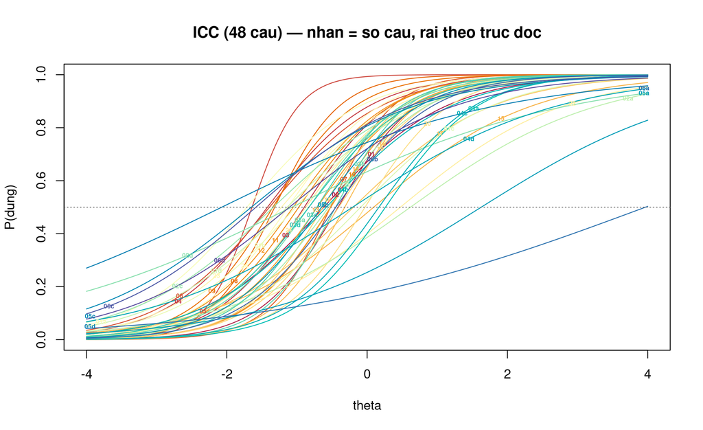

### IIC — Thông tin từng câu

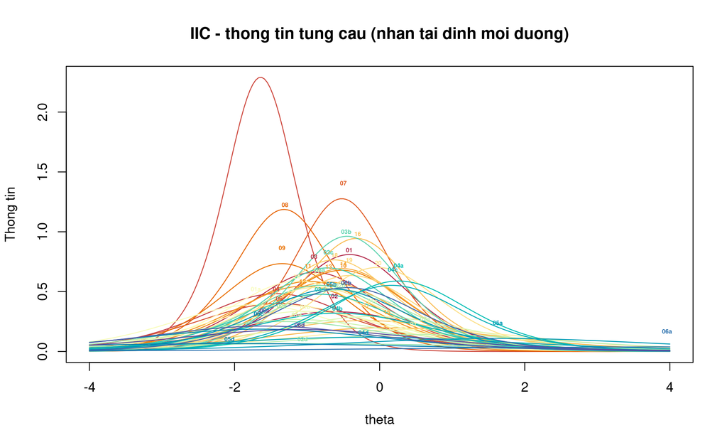

### TIF & SE(θ)

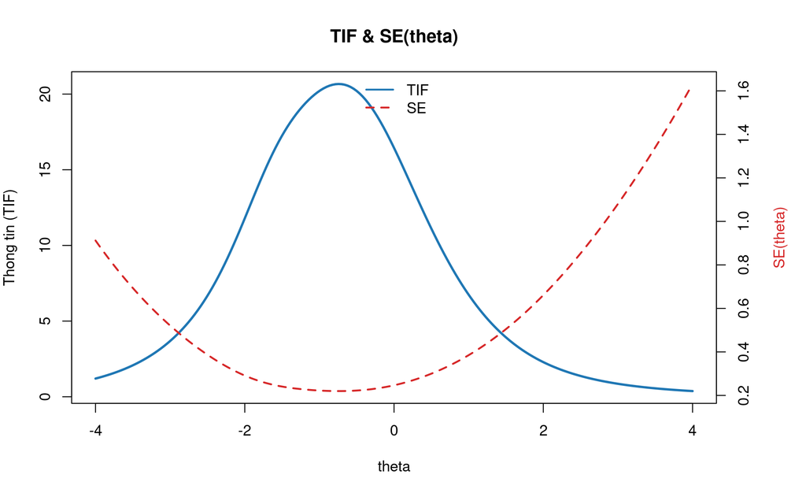

### TCC — Đường cong đặc trưng bài test

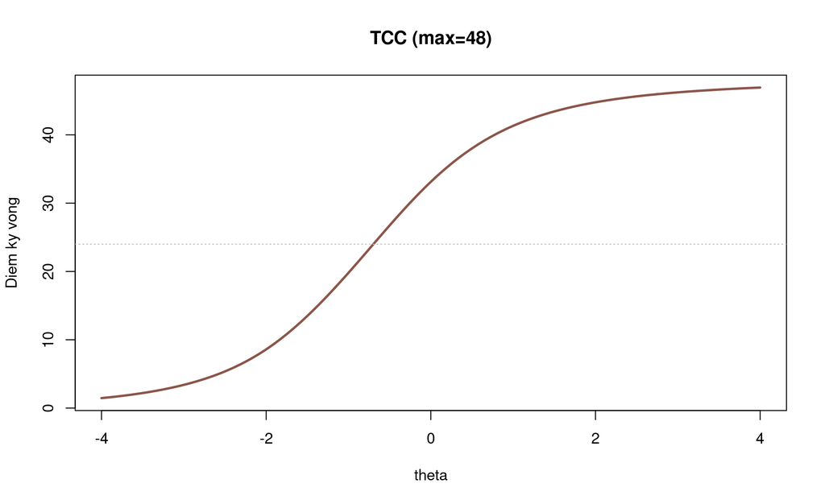

### Độ tin cậy theo năng lực

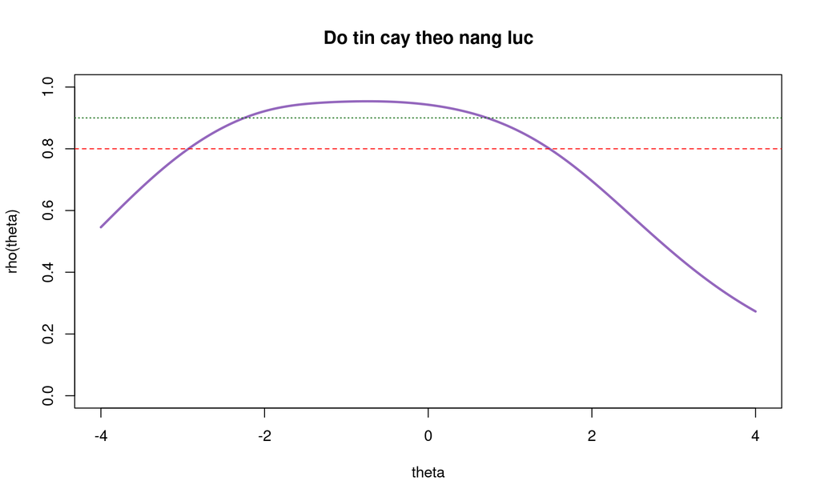

### Scatter a vs b

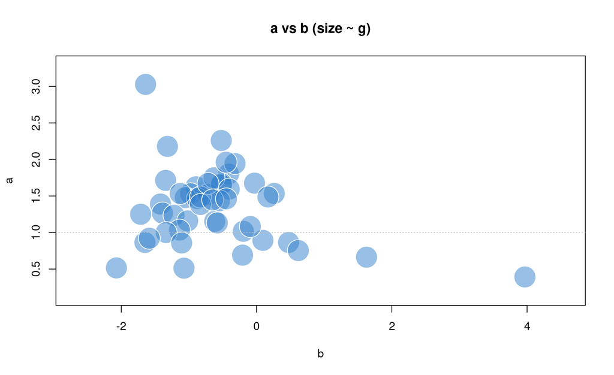

### Wright map (item–person)

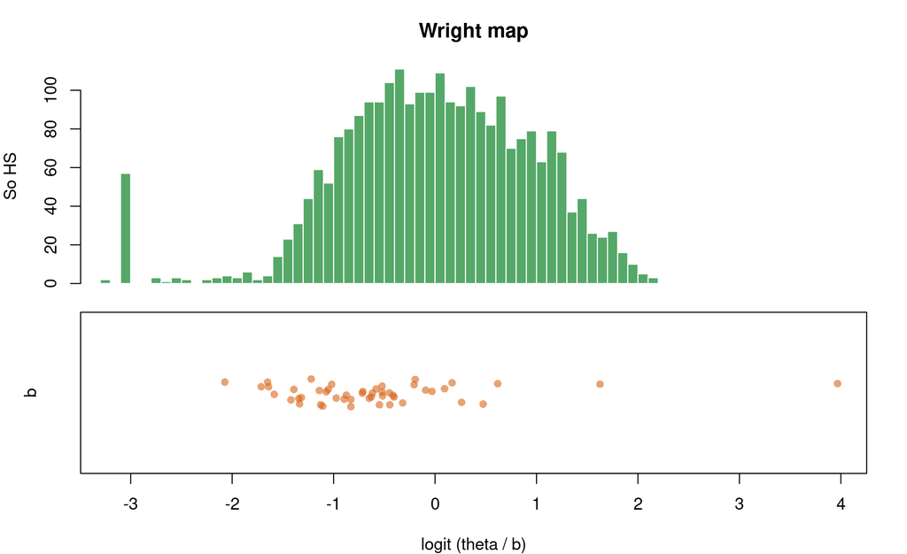

### Item fit: thực nghiệm vs mô hình

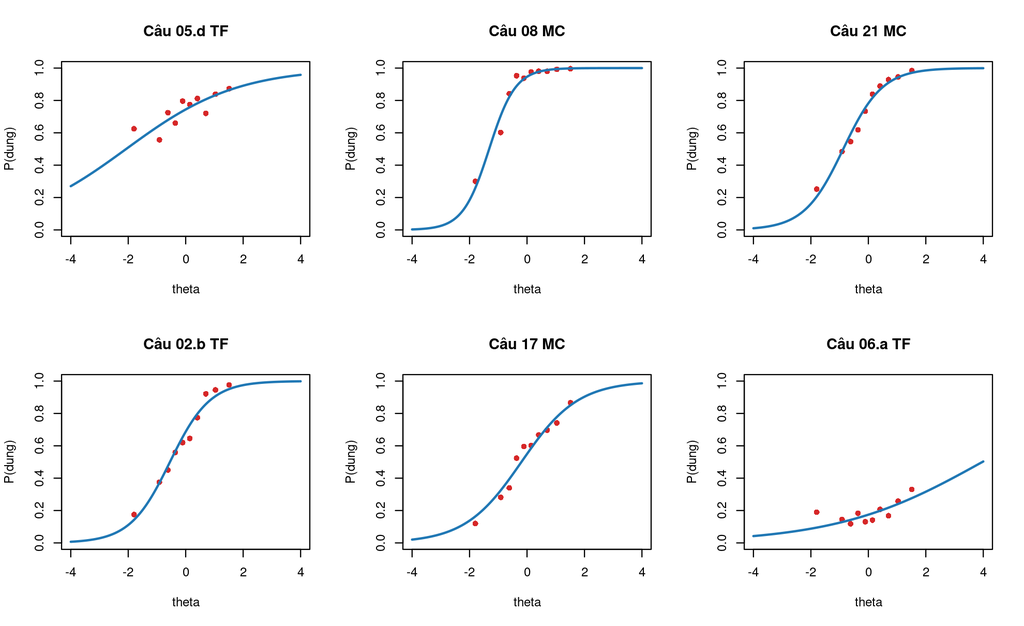

### Phụ thuộc cục bộ Q3

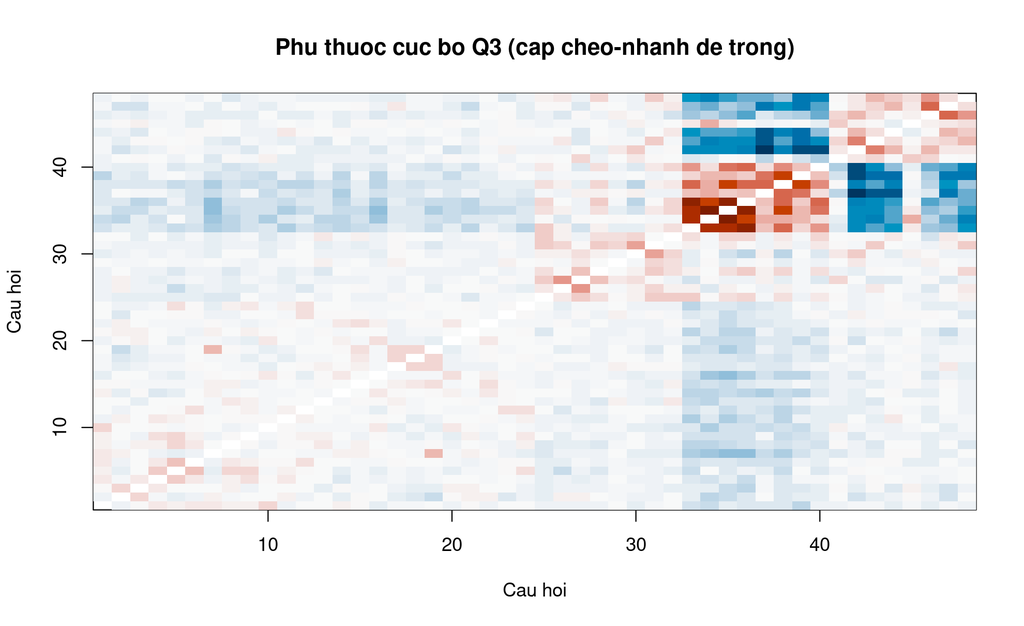

### Person fit

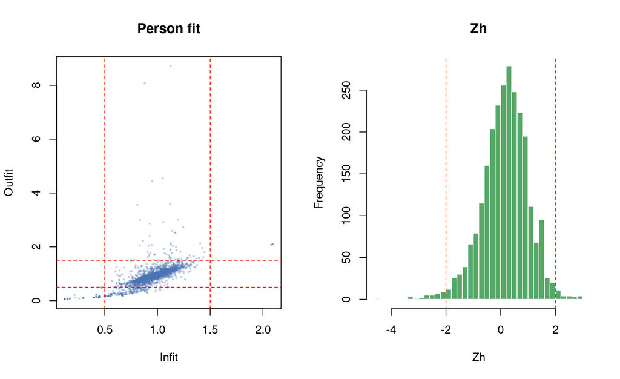

### Item fit (Bock X²)

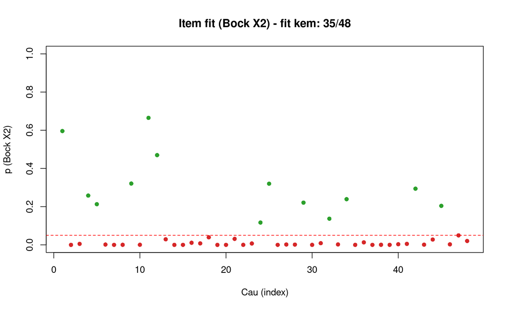

## 5.3 Mô hình 3PL

### Phân bố tham số item

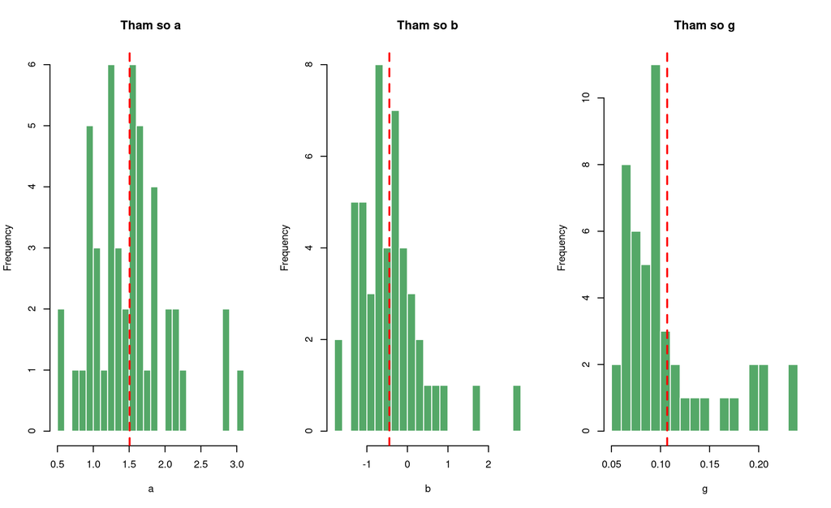

### Bảng tham số item (theo Câu)

Tham số item 3PL — cỡ mẫu N, số đúng, a, b, g (bấm cột để sắp xếp)

| Câu | Cỡ mẫu (N) | Số đúng | a | b | g |
| --- | --- | --- | --- | --- | --- |
| Câu 01 MC | 2530 | 1584 | 2.857 | -0.054 | 0.203 |
| Câu 02 MC | 2531 | 1626 | 1.237 | -0.429 | 0.093 |
| Câu 03 MC | 2529 | 1871 | 1.784 | -0.696 | 0.128 |
| Câu 04 MC | 2532 | 2075 | 1.393 | -1.318 | 0.095 |
| Câu 05 MC | 2532 | 2348 | 3.056 | -1.637 | 0.089 |
| Câu 06 MC | 2531 | 2028 | 1.285 | -1.270 | 0.093 |
| Câu 07 MC | 2530 | 1697 | 2.812 | -0.337 | 0.119 |
| Câu 08 MC | 2530 | 2168 | 2.230 | -1.240 | 0.097 |
| Câu 09 MC | 2527 | 2110 | 1.699 | -1.288 | 0.078 |
| Câu 10 MC | 2526 | 1642 | 1.851 | -0.334 | 0.109 |
| Câu 11 MC | 2527 | 1896 | 1.544 | -0.884 | 0.075 |
| Câu 12 MC | 2527 | 1926 | 1.473 | -0.978 | 0.070 |
| Câu 13 MC | 2526 | 1744 | 1.558 | -0.611 | 0.069 |
| Câu 14 MC | 2526 | 1641 | 1.851 | -0.344 | 0.102 |
| Câu 15 MC | 2528 | 1227 | 0.950 | 0.259 | 0.063 |
| Câu 16 MC | 2526 | 1523 | 2.192 | -0.186 | 0.079 |
| Câu 17 MC | 2526 | 1377 | 1.059 | -0.052 | 0.063 |
| Câu 18 MC | 2525 | 1724 | 1.805 | -0.532 | 0.069 |
| Câu 19 MC | 2526 | 1558 | 1.646 | -0.314 | 0.055 |
| Câu 20 MC | 2526 | 1300 | 2.140 | 0.165 | 0.106 |
| Câu 21 MC | 2527 | 1828 | 1.531 | -0.731 | 0.093 |
| Câu 22 MC | 2525 | 1049 | 0.931 | 0.629 | 0.057 |
| Câu 23 MC | 2527 | 1944 | 1.227 | -1.136 | 0.074 |
| Câu 24 MC | 2526 | 1974 | 1.525 | -1.066 | 0.066 |
| Câu 01.a TF | 2525 | 2137 | 1.210 | -1.657 | 0.090 |
| Câu 01.b TF | 2525 | 1827 | 1.231 | -0.771 | 0.133 |
| Câu 01.c TF | 2525 | 1324 | 1.200 | 0.116 | 0.090 |
| Câu 01.d TF | 2525 | 1842 | 1.041 | -0.973 | 0.099 |
| Câu 02.a TF | 2526 | 1011 | 0.822 | 0.827 | 0.068 |
| Câu 02.b TF | 2526 | 1631 | 1.556 | -0.369 | 0.099 |
| Câu 02.c TF | 2526 | 1911 | 0.996 | -1.198 | 0.091 |
| Câu 02.d TF | 2526 | 1586 | 0.527 | -0.647 | 0.115 |
| Câu 03.a TF | 1307 | 902 | 1.499 | -0.704 | 0.089 |
| Câu 03.b TF | 1307 | 806 | 2.030 | -0.347 | 0.069 |
| Câu 03.c TF | 1307 | 882 | 1.678 | -0.615 | 0.077 |
| Câu 03.d TF | 1307 | 893 | 1.385 | -0.718 | 0.080 |
| Câu 04.a TF | 1297 | 548 | 2.006 | 0.444 | 0.093 |
| Câu 04.b TF | 1297 | 797 | 1.172 | -0.406 | 0.088 |
| Câu 04.c TF | 1297 | 580 | 1.688 | 0.310 | 0.070 |
| Câu 04.d TF | 1297 | 677 | 0.717 | 0.088 | 0.092 |
| Câu 05.a TF | 1296 | 357 | 1.547 | 1.613 | 0.160 |
| Câu 05.b TF | 1296 | 888 | 1.659 | -0.357 | 0.171 |
| Câu 05.c TF | 1296 | 1025 | 0.933 | -1.130 | 0.232 |
| Câu 05.d TF | 1296 | 961 | 0.547 | -1.376 | 0.196 |
| Câu 06.a TF | 1297 | 238 | 1.387 | 2.653 | 0.142 |
| Câu 06.b TF | 1297 | 823 | 1.859 | -0.090 | 0.197 |
| Câu 06.c TF | 1297 | 1030 | 0.973 | -1.180 | 0.201 |
| Câu 06.d TF | 1297 | 921 | 1.008 | -0.498 | 0.237 |

### ICC — Đường cong đặc trưng câu hỏi

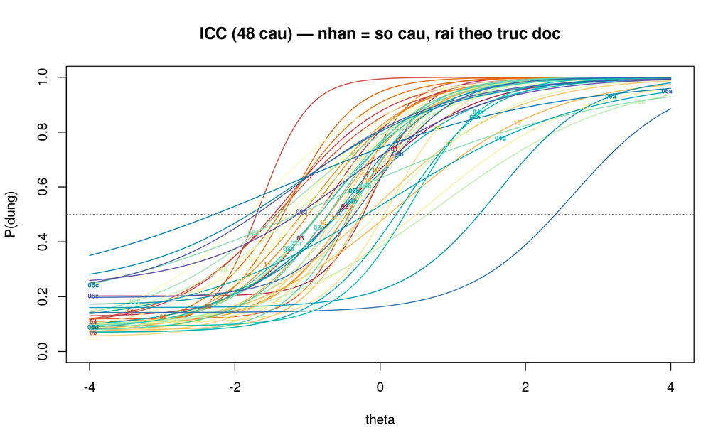

### IIC — Thông tin từng câu

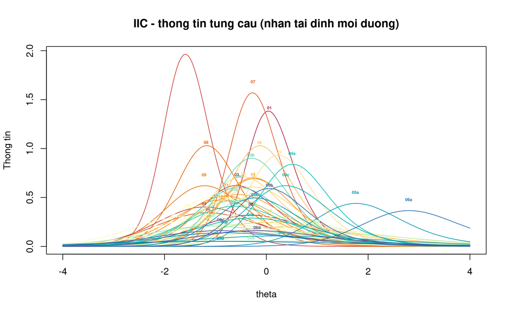

### TIF & SE(θ)

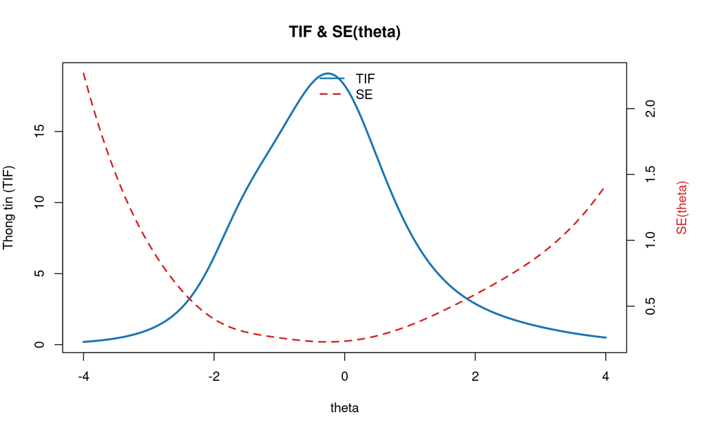

### TCC — Đường cong đặc trưng bài test

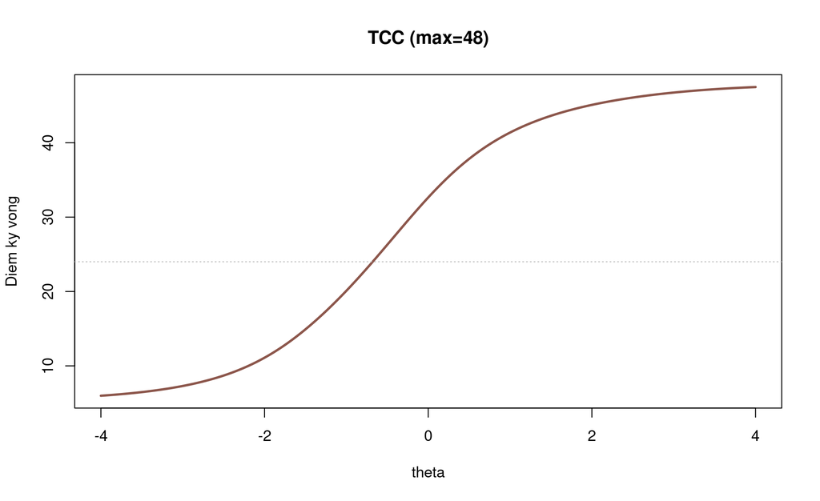

### Độ tin cậy theo năng lực

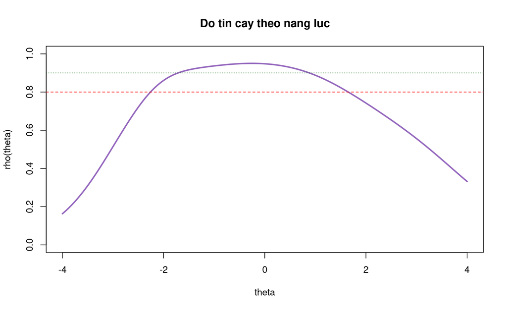

### Scatter a vs b

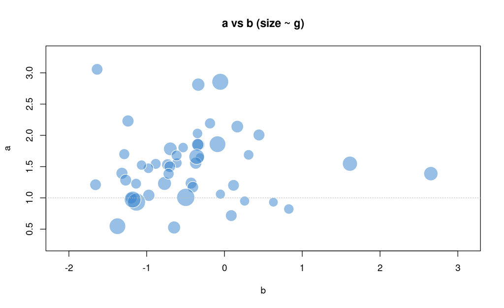

### Wright map (item–person)

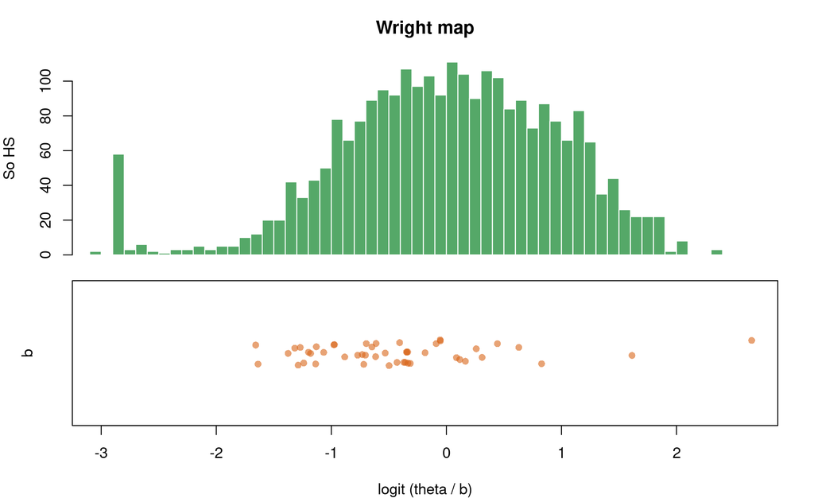

### Item fit: thực nghiệm vs mô hình

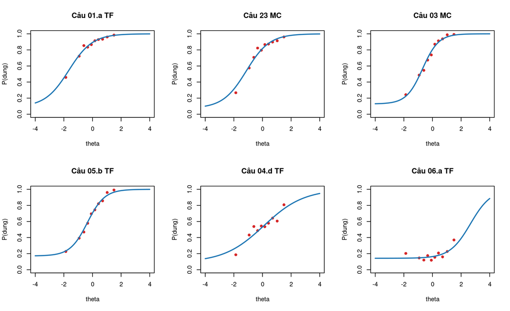

### Phụ thuộc cục bộ Q3

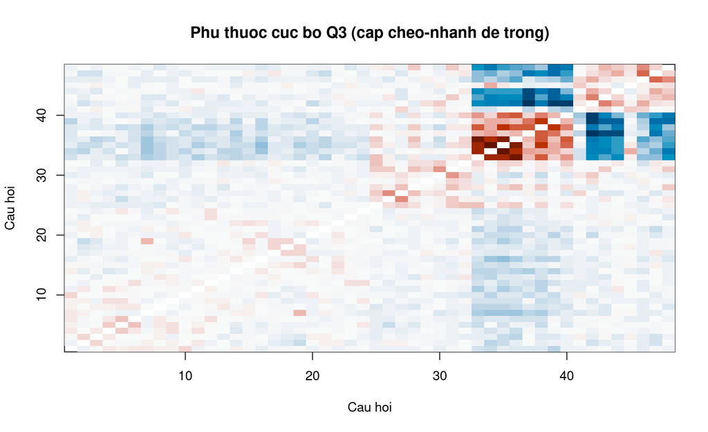

### Person fit

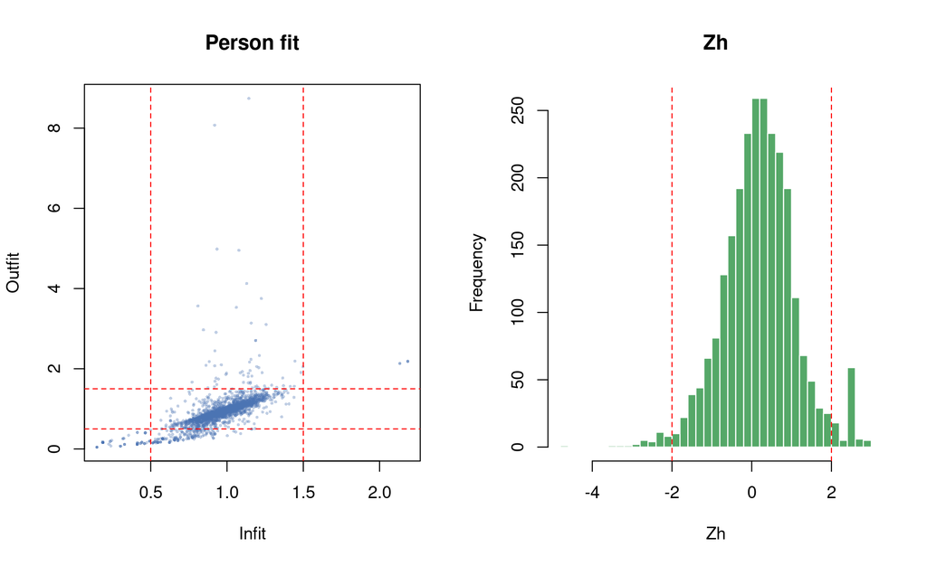

### Item fit (Bock X²)

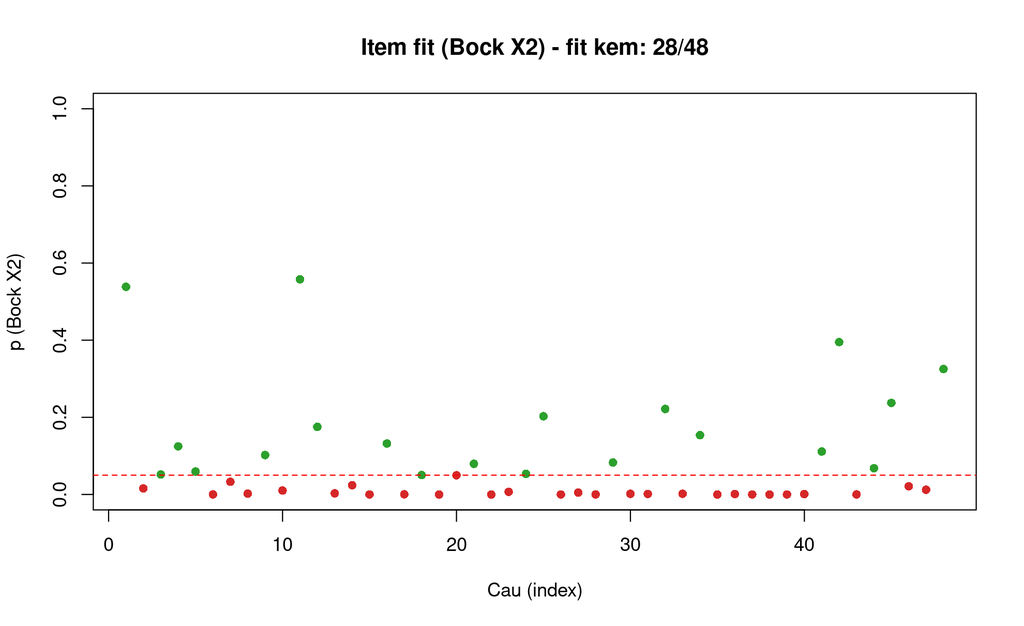

## 5.4 So sánh chéo giữa 1PL/2PL/3PL

### Độ khó b qua các mô hình

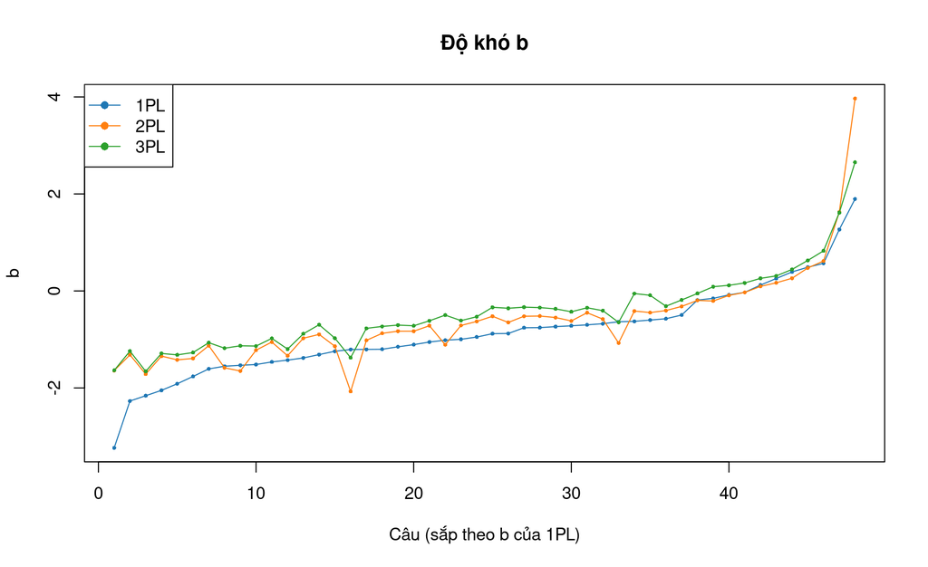

### Năng lực θ giữa các mô hình

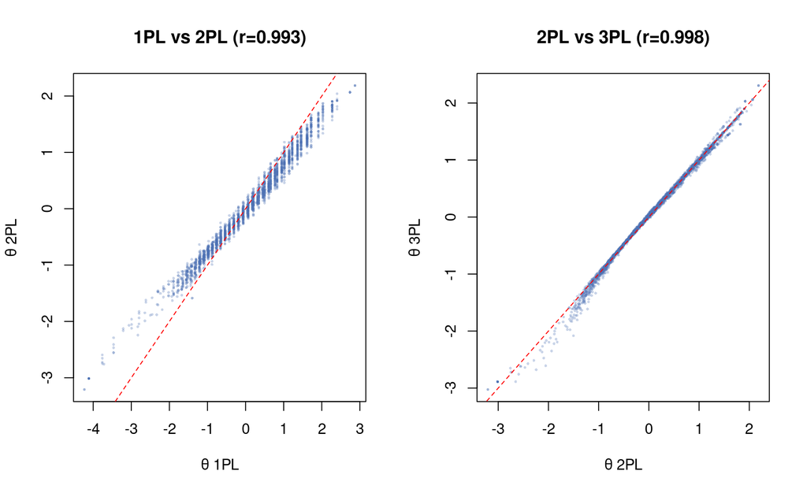

### Scree — kiểm tra đơn chiều

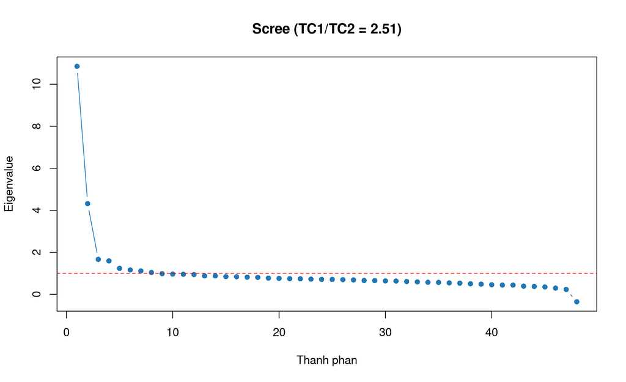

# 6 Phân tích mở rộng — Đề thi thử Tốt nghiệp THPT môn Tin học - Lần 1 (2025 - 2026)

## CTT và đối chiếu CTT–IRT

- **Cronbach’s α = 0.916 · KR-20 = 0.895** · 48 item · 2543 HS.
- Câu có độ phân biệt CTT yếu (r < 0,20): **2/48** — nên rà soát.

Thống kê item: cỡ mẫu N, số đúng, p, r (CTT) đối chiếu a, b (IRT) — bấm cột để sắp xếp

| Câu | Cỡ mẫu (N) | Số đúng | Độ khó p (CTT) | Phân biệt r (CTT) | b (IRT 2PL) | a (IRT 2PL) |
| --- | --- | --- | --- | --- | --- | --- |
| Câu 01 MC | 2530 | 1584 | 0.626 | 0.531 | -0.414 | 1.800 |
| Câu 02 MC | 2531 | 1626 | 0.642 | 0.417 | -0.618 | 1.153 |
| Câu 03 MC | 2529 | 1871 | 0.740 | 0.496 | -0.895 | 1.626 |
| Câu 04 MC | 2532 | 2075 | 0.820 | 0.432 | -1.421 | 1.390 |
| Câu 05 MC | 2532 | 2348 | 0.927 | 0.531 | -1.641 | 3.027 |
| Câu 06 MC | 2531 | 2028 | 0.801 | 0.422 | -1.391 | 1.267 |
| Câu 07 MC | 2530 | 1697 | 0.671 | 0.589 | -0.522 | 2.260 |
| Câu 08 MC | 2530 | 2168 | 0.857 | 0.533 | -1.318 | 2.179 |
| Câu 09 MC | 2527 | 2110 | 0.835 | 0.482 | -1.343 | 1.714 |
| Câu 10 MC | 2526 | 1642 | 0.650 | 0.508 | -0.522 | 1.647 |
| Câu 11 MC | 2527 | 1896 | 0.750 | 0.480 | -0.974 | 1.531 |
| Câu 12 MC | 2527 | 1926 | 0.762 | 0.473 | -1.053 | 1.478 |
| Câu 13 MC | 2526 | 1744 | 0.690 | 0.500 | -0.711 | 1.523 |
| Câu 14 MC | 2526 | 1641 | 0.650 | 0.515 | -0.517 | 1.664 |
| Câu 15 MC | 2528 | 1227 | 0.485 | 0.365 | 0.094 | 0.893 |
| Câu 16 MC | 2526 | 1523 | 0.603 | 0.555 | -0.319 | 1.944 |
| Câu 17 MC | 2526 | 1377 | 0.545 | 0.398 | -0.195 | 1.017 |
| Câu 18 MC | 2525 | 1724 | 0.683 | 0.538 | -0.629 | 1.750 |
| Câu 19 MC | 2526 | 1558 | 0.617 | 0.517 | -0.404 | 1.594 |
| Câu 20 MC | 2526 | 1300 | 0.515 | 0.509 | -0.030 | 1.676 |
| Câu 21 MC | 2527 | 1828 | 0.723 | 0.471 | -0.874 | 1.464 |
| Câu 22 MC | 2525 | 1049 | 0.415 | 0.337 | 0.474 | 0.864 |
| Câu 23 MC | 2527 | 1944 | 0.769 | 0.436 | -1.221 | 1.236 |
| Câu 24 MC | 2526 | 1974 | 0.781 | 0.481 | -1.128 | 1.534 |
| Câu 01.a TF | 2525 | 2137 | 0.846 | 0.415 | -1.713 | 1.250 |
| Câu 01.b TF | 2525 | 1827 | 0.724 | 0.420 | -1.018 | 1.159 |
| Câu 01.c TF | 2525 | 1324 | 0.524 | 0.407 | -0.092 | 1.082 |
| Câu 01.d TF | 2525 | 1842 | 0.730 | 0.392 | -1.140 | 1.034 |
| Câu 02.a TF | 2526 | 1011 | 0.400 | 0.309 | 0.618 | 0.753 |
| Câu 02.b TF | 2526 | 1631 | 0.646 | 0.485 | -0.548 | 1.435 |
| Câu 02.c TF | 2526 | 1911 | 0.757 | 0.383 | -1.336 | 1.000 |
| Câu 02.d TF | 2526 | 1586 | 0.628 | 0.231 | -1.072 | 0.512 |
| Câu 03.a TF | 1307 | 902 | 0.690 | 0.524 | -0.830 | 1.486 |
| Câu 03.b TF | 1307 | 806 | 0.617 | 0.596 | -0.449 | 1.962 |
| Câu 03.c TF | 1307 | 882 | 0.675 | 0.559 | -0.717 | 1.671 |
| Câu 03.d TF | 1307 | 893 | 0.683 | 0.510 | -0.830 | 1.384 |
| Câu 04.a TF | 1297 | 548 | 0.423 | 0.486 | 0.261 | 1.535 |
| Câu 04.b TF | 1297 | 797 | 0.614 | 0.450 | -0.581 | 1.132 |
| Câu 04.c TF | 1297 | 580 | 0.447 | 0.489 | 0.168 | 1.487 |
| Câu 04.d TF | 1297 | 677 | 0.522 | 0.316 | -0.207 | 0.690 |
| Câu 05.a TF | 1296 | 357 | 0.275 | 0.208 | 1.626 | 0.663 |
| Câu 05.b TF | 1296 | 888 | 0.685 | 0.434 | -0.649 | 1.446 |
| Câu 05.c TF | 1296 | 1025 | 0.791 | 0.242 | -1.650 | 0.864 |
| Câu 05.d TF | 1296 | 961 | 0.742 | 0.159 | -2.072 | 0.516 |
| Câu 06.a TF | 1297 | 238 | 0.184 | 0.085 | 3.967 | 0.392 |
| Câu 06.b TF | 1297 | 823 | 0.635 | 0.437 | -0.446 | 1.461 |
| Câu 06.c TF | 1297 | 1030 | 0.794 | 0.262 | -1.585 | 0.922 |
| Câu 06.d TF | 1297 | 921 | 0.710 | 0.280 | -1.108 | 0.857 |

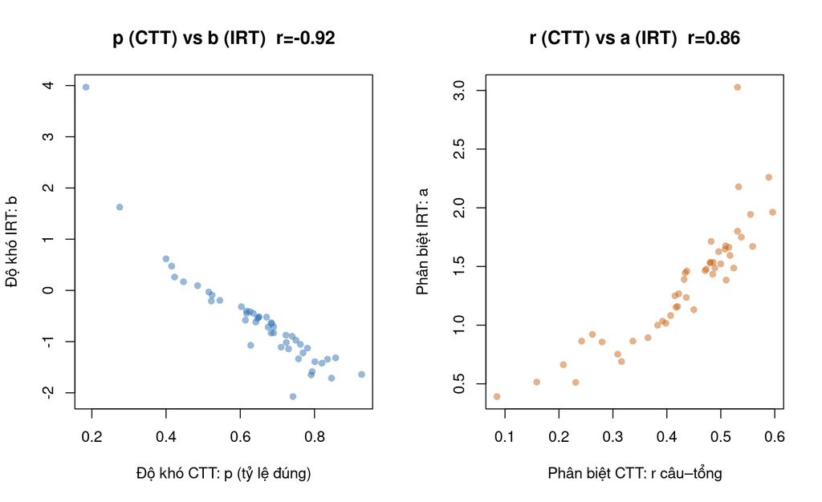

> **Cách đọc:** p (CTT) và b (IRT) nghịch biến gần tuyệt đối — câu dễ (p cao) có b thấp; độ phân biệt CTT (r câu–tổng) tương ứng tham số a của IRT. Khác biệt cốt lõi: p **phụ thuộc mẫu**, còn b **không** (xem mục Tính bất biến).

Đối chiếu CTT–IRT theo các tiêu chí chính (theo tài liệu nền, mục 2.2)

| Tiêu chí | CTT | IRT |
| --- | --- | --- |
| Đơn vị phân tích | Cấp độ đề (điểm tổng) | Cấp độ câu hỏi |
| Đại lượng năng lực | Điểm thô, phụ thuộc đề | θ trên thang chung, độc lập đề |
| Tham số câu hỏi | Độ khó = tỷ lệ đúng; phân biệt = r câu–tổng | a, b, c cùng thang với θ |
| Tính bất biến | Không (đổi theo nhóm/đề) | Có (khi mô hình phù hợp) |
| Sai số đo | Một giá trị chung mọi HS | Thay đổi theo θ (hàm thông tin) |
| Độ tin cậy | Qua ‘hai đề tương đương’ | Hàm thông tin I(θ) |
| Dự báo ứng đáp | Không trả lời ‘P đúng câu này?’ | Trả lời trực tiếp qua P(θ) |

## Các cách ước lượng tham số IRT

### Ước lượng năng lực θ: ML · WLE · MAP · EAP

Bốn cách ước lượng θ trên cùng mô hình 2PL (81 HS điểm biên)

| Bộ ước lượng | Loại | SD(θ) — HS không biên | Điểm biên (đúng/sai toàn bộ) |
| --- | --- | --- | --- |
| ML | Tần suất | 1.004 | ±∞ → bị chặn (81 HS) |
| WLE | Tần suất | 0.919 | ±∞ → bị chặn (81 HS) |
| MAP | Bayes (mode) | 0.815 | Hữu hạn |
| EAP | Bayes (kỳ vọng) | 0.847 | Hữu hạn |

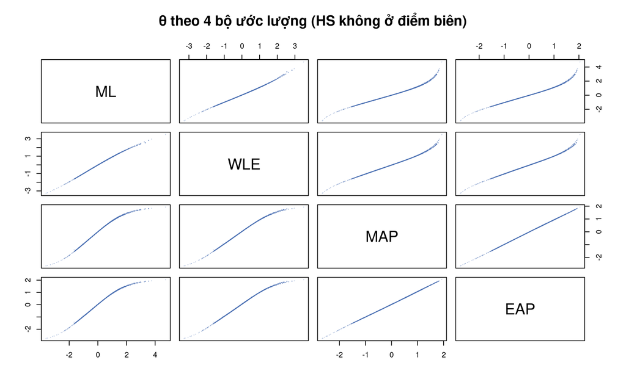

> **Cách đọc:** bốn cách tương quan rất cao nhưng **không trùng**. ML/WLE (tần suất) không có tiên nghiệm nên **không định được** HS đúng/sai toàn bộ (điểm biên — mục 1.6); MAP/EAP (Bayes) thêm tiên nghiệm N(0,1) nên ổn định ở hai cực nhưng **co rút** về 0 (SD nhỏ hơn — mục 3.7).

### Cùng một đường cong, nhiều cách tham số hoá

Cùng ICC, 3 metric: IRT (a,b) · slope–intercept (a,d) · vòm chuẩn (a*)

| Câu | a | b | d = −a·b (slope–intercept) | a* = a/1,702 (vòm chuẩn) |
| --- | --- | --- | --- | --- |
| Câu 05.d TF | 0.516 | -2.072 | 1.068 | 0.303 |
| Câu 08 MC | 2.179 | -1.318 | 2.871 | 1.280 |
| Câu 21 MC | 1.464 | -0.874 | 1.279 | 0.860 |
| Câu 02.b TF | 1.435 | -0.548 | 0.786 | 0.843 |
| Câu 17 MC | 1.017 | -0.195 | 0.199 | 0.598 |
| Câu 06.a TF | 0.392 | 3.967 | -1.555 | 0.230 |

> Logit: ln[P/(1−P)] = a(θ−b) = a·θ + d với d = −a·b. Logistic ↔︎ vòm chuẩn nối qua hằng số D≈1,702 (Haley 1952): nhân a với 1/1,702 để đổi metric. **Cùng một đường cong, chỉ khác cách viết** (mục 3.4).

### Thuật toán ước lượng: EM vs MH-RM

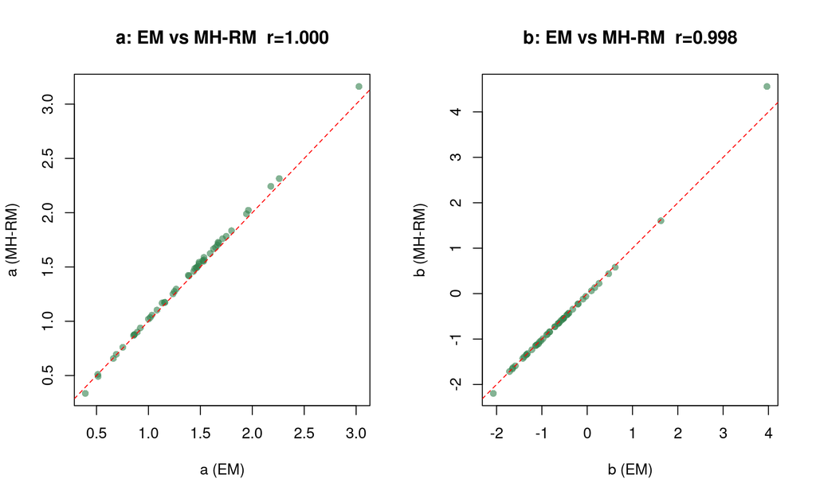

> Hai thuật toán tối ưu khác hẳn nhau (EM tất định vs MH-RM Monte Carlo) cho **cùng** ước lượng (r≈1) ⇒ con số ổn định, không phải artefact thuật toán. EM dùng ở phần chính; MH-RM ~82s.

## Tính bất biến & DIF — chia lại mẫu

### Tách ngẫu nhiên 2 nhóm → bất biến tham số

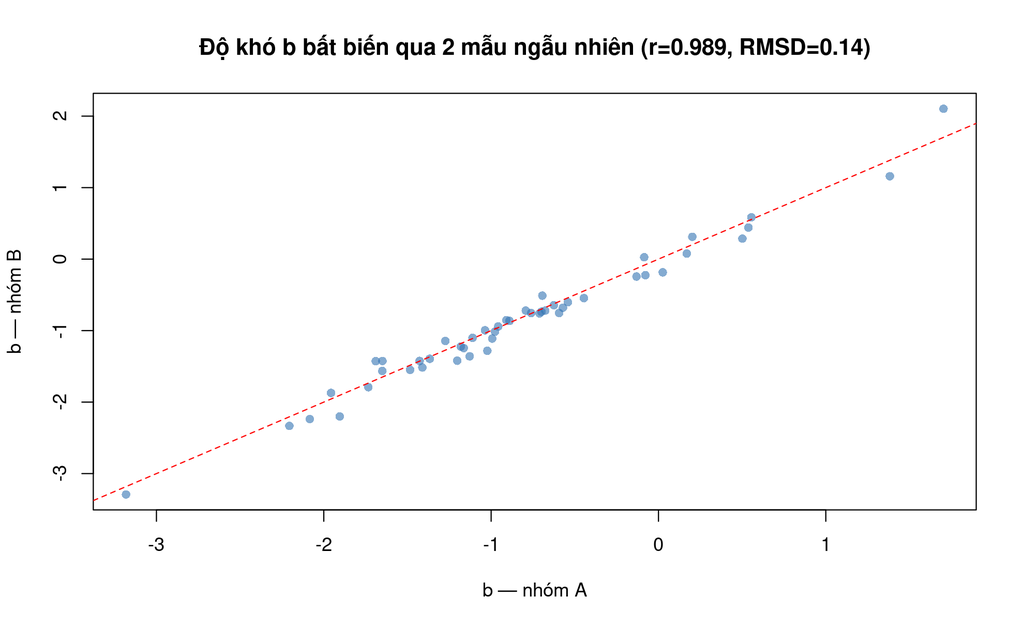

> Hai nhóm HS độc lập cho **cùng** độ khó câu (bám đường chéo) ⇒ tham số câu **không phụ thuộc mẫu** (sample-free). Đây là ‘hòn đá tảng’ (mục 2.3) mà CTT không có.

### Tách theo năng lực → CTT đổi theo nhóm, IRT giữ nguyên

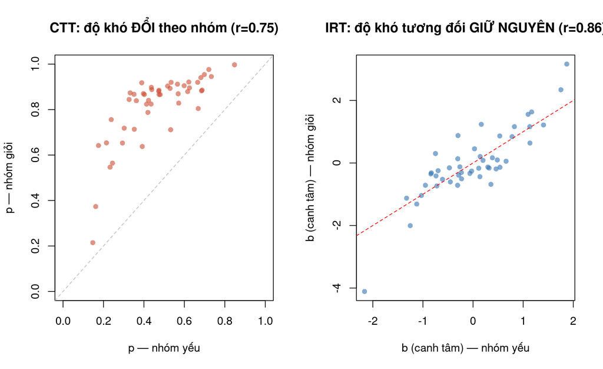

> Đây là ‘Hình 4 — hòn đá tảng’ tái hiện trên dữ liệu thật: tỷ lệ đúng (độ khó CTT) **co dãn theo năng lực nhóm** (nhóm giỏi thấy mọi câu dễ hơn), còn **thứ tự & khoảng cách độ khó IRT được bảo toàn** sau canh tâm. Vị trí tuyệt đối b lệch một hằng số giữa 2 nhóm ⇒ cần *so bằng/anchor* để gộp thang (mục 3.10).

### Chênh độ khó giữa 2 mẫu ngẫu nhiên (kiểm tra ổn định)

8 câu chênh độ khó nhiều nhất giữa 2 mẫu ngẫu nhiên

| Câu | b_A | b_B | Δb |
| --- | --- | --- | --- |
| Câu 06.a TF | 1.70 | 2.10 | -0.40 |
| Câu 09 MC | -1.91 | -2.20 | 0.29 |
| Câu 06.c TF | -1.69 | -1.43 | -0.26 |
| Câu 03.a TF | -1.02 | -1.28 | 0.26 |
| Câu 01.d TF | -1.13 | -1.36 | 0.23 |
| Câu 05.c TF | -1.65 | -1.42 | -0.22 |
| Câu 05.a TF | 1.38 | 1.16 | 0.22 |
| Câu 03 MC | -1.20 | -1.42 | 0.22 |

> Đây là 2 mẫu **ngẫu nhiên** nên Δb đo **sai số lấy mẫu**, KHÔNG phải DIF. Số câu |Δb| > 0,5 logit: **0/48**; Δb nhỏ ⇒ tham số câu **ổn định qua mẫu**, củng cố tính bất biến. (DIF thật — chênh theo nhóm có ý nghĩa — xem mục dưới.)

### DIF theo nhánh: KHMT vs Tin ứng dụng (trên câu neo chung)

- Nhóm: **KHMT 1218 HS** · **Tin ứng dụng 1193 HS** · kiểm định **32 câu neo**.
- Câu neo có **DIF** (p hiệu chỉnh BH < 0,05): **7/32**.

DIF câu neo giữa 2 nhánh — X² Wald (df=2: a & b), sắp theo p; bấm cột để sắp xếp

| Câu | X² (a&b) | df | p | p hiệu chỉnh | DIF |
| --- | --- | --- | --- | --- | --- |
| Câu 23 MC | 22.59 | 2 | 1.24e-05 | 0.000397 | ⚠ có |
| Câu 02.c TF | 15.55 | 2 | 4.21e-04 | 0.004820 | ⚠ có |
| Câu 01.a TF | 15.40 | 2 | 4.52e-04 | 0.004820 | ⚠ có |
| Câu 19 MC | 14.20 | 2 | 8.26e-04 | 0.006610 | ⚠ có |
| Câu 10 MC | 13.39 | 2 | 1.24e-03 | 0.007910 | ⚠ có |
| Câu 01 MC | 10.86 | 2 | 4.39e-03 | 0.022900 | ⚠ có |
| Câu 07 MC | 10.59 | 2 | 5.01e-03 | 0.022900 | ⚠ có |
| Câu 02.d TF | 7.88 | 2 | 1.94e-02 | 0.077800 |  |
| Câu 18 MC | 7.55 | 2 | 2.30e-02 | 0.081700 |  |
| Câu 12 MC | 5.86 | 2 | 5.35e-02 | 0.171000 |  |
| Câu 24 MC | 5.43 | 2 | 6.63e-02 | 0.193000 |  |
| Câu 01.b TF | 4.93 | 2 | 8.48e-02 | 0.224000 |  |
| Câu 04 MC | 4.79 | 2 | 9.11e-02 | 0.224000 |  |
| Câu 01.c TF | 3.80 | 2 | 1.49e-01 | 0.331000 |  |
| Câu 21 MC | 3.58 | 2 | 1.67e-01 | 0.331000 |  |
| Câu 17 MC | 3.57 | 2 | 1.68e-01 | 0.331000 |  |
| Câu 08 MC | 3.48 | 2 | 1.76e-01 | 0.331000 |  |
| Câu 15 MC | 3.32 | 2 | 1.90e-01 | 0.338000 |  |
| Câu 16 MC | 3.09 | 2 | 2.14e-01 | 0.360000 |  |
| Câu 14 MC | 2.32 | 2 | 3.14e-01 | 0.503000 |  |
| Câu 03 MC | 1.85 | 2 | 3.96e-01 | 0.604000 |  |
| Câu 05 MC | 1.54 | 2 | 4.63e-01 | 0.673000 |  |
| Câu 20 MC | 1.37 | 2 | 5.05e-01 | 0.677000 |  |
| Câu 06 MC | 1.32 | 2 | 5.17e-01 | 0.677000 |  |
| Câu 02.b TF | 1.28 | 2 | 5.29e-01 | 0.677000 |  |
| Câu 13 MC | 1.00 | 2 | 6.06e-01 | 0.746000 |  |
| Câu 11 MC | 0.92 | 2 | 6.31e-01 | 0.748000 |  |
| Câu 22 MC | 0.43 | 2 | 8.07e-01 | 0.923000 |  |
| Câu 09 MC | 0.28 | 2 | 8.71e-01 | 0.927000 |  |
| Câu 02 MC | 0.25 | 2 | 8.84e-01 | 0.927000 |  |
| Câu 02.a TF | 0.22 | 2 | 8.98e-01 | 0.927000 |  |
| Câu 01.d TF | 0.01 | 2 | 9.95e-01 | 0.995000 |  |

> **Cách đọc:** học sinh chọn KHMT và chọn Tin ứng dụng có nền tảng khác nhau. Câu neo **DIF** nghĩa là ở **cùng năng lực θ**, hai nhóm có xác suất đúng khác nhau ⇒ **câu thiên lệch theo nhóm** (mục 2.2, 3.9). Hệ quả: khi muốn **so θ trực tiếp giữa hai nhánh**, chỉ nên neo thang bằng các câu **không** DIF; câu DIF nên rà soát nội dung (có thiên về một phân môn không).

## Chẩn đoán bổ sung

### Độ phù hợp tuyệt đối (M2, RMSEA, SRMSR, CFI/TLI)

Độ phù hợp tuyệt đối từng mô hình

| Model | M2 | df | p | RMSEA | SRMSR | CFI | TLI |
| --- | --- | --- | --- | --- | --- | --- | --- |
| 1PL | 10179.5 | 1127 | 0 | 0.056 | 0.423 | 0.901 | 0.901 |
| 2PL | 7569.8 | 1080 | 0 | 0.049 | 0.408 | 0.929 | 0.926 |
| 3PL | 6753.0 | 1032 | 0 | 0.047 | 0.405 | 0.938 | 0.932 |

> **Ngưỡng:** RMSEA < 0,06 · SRMSR < 0,08 · CFI/TLI > 0,95 là phù hợp tốt. AIC/BIC chỉ chọn mô hình *ít tệ hơn*; M2 cho biết mô hình tốt nhất có **đủ tốt tuyệt đối** không. RMSEA/SRMSR cao ⇒ vi phạm giả định (thường do phụ thuộc cục bộ câu chùm) ⇒ tính bất biến lung lay (mục 3.8).

### Item infit/outfit MNSQ (mô hình 1PL/Rasch)

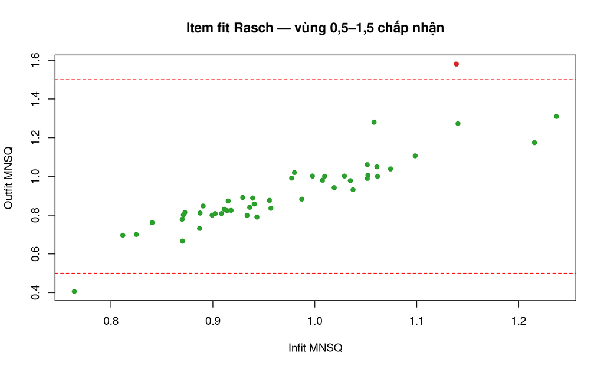

- Câu lệch fit (MNSQ ngoài 0,5–1,5): **2/48**.

Câu lệch fit Rasch

| Câu | infit | outfit |
| --- | --- | --- |
| Câu 05 MC | 0.76 | 0.41 |
| Câu 06.a TF | 1.14 | 1.58 |

> infit/outfit MNSQ là chỉ số fit chuẩn của Rasch (mục 1.7, 3.8): quanh 1 là khớp, >1,5 là nhiễu (câu đo không nhất quán với năng lực).

### Độ tin cậy số

- Marginal reliability (IRT) = **0.91** · Empirical reliability = **0.898** · Cronbach’s α (CTT) = **0.916**.

> IRT thay ‘độ tin cậy một số’ của CTT bằng độ tin cậy biến thiên theo θ (đã vẽ ở ρ(θ)); marginal_rxx tổng hợp lại thành một số để đối chiếu với α.

### Kiểm định đơn chiều

- (Trên 32 câu neo chung, dữ liệu đầy đủ) Tỷ lệ eigenvalue λ1/λ2 = **5.68** — càng lớn càng đơn chiều.
- Parallel analysis (tetrachoric) gợi ý **9** nhân tố.

> Tính trên **câu neo chung** vì hai nhánh elective không có HS làm chung ⇒ không tính được tương quan trực tiếp (chúng chỉ **liên kết qua mô hình IRT**). Nếu >1 nhân tố, phần lớn do **phụ thuộc cục bộ câu chùm** (đọc cùng LD bên dưới), không hẳn đa chiều năng lực.

### Phụ thuộc cục bộ: cặp |Q3| lớn

10 cặp câu phụ thuộc cục bộ mạnh nhất (chỉ cặp đủ HS làm chung)

| Câu i | Câu j | Q3 |
| --- | --- | --- |
| Câu 04.a TF | Câu 05.b TF | -0.510 |
| Câu 04.d TF | Câu 05.b TF | -0.469 |
| Câu 04.c TF | Câu 05.b TF | -0.468 |
| Câu 03.b TF | Câu 03.c TF | 0.463 |
| Câu 04.a TF | Câu 05.d TF | -0.449 |
| Câu 03.a TF | Câu 03.d TF | 0.447 |
| Câu 04.a TF | Câu 05.c TF | -0.445 |
| Câu 03.c TF | Câu 03.d TF | 0.440 |
| Câu 04.c TF | Câu 05.d TF | -0.407 |
| Câu 04.c TF | Câu 05.c TF | -0.399 |

### Quy đổi θ ↔︎ điểm thực (đường đặc trưng đề)

θ → điểm thực kỳ vọng (đề 48 item)

| θ | Điểm thực kỳ vọng τ(θ) | % trên tổng |
| --- | --- | --- |
| -3 | 3.4 | 7.1 |
| -2 | 8.6 | 17.9 |
| -1 | 19.8 | 41.3 |
| 0 | 33.1 | 69.0 |
| 1 | 41.3 | 86.1 |
| 2 | 44.8 | 93.3 |
| 3 | 46.2 | 96.3 |

> Cầu nối thang θ trừu tượng ↔︎ ‘số câu đúng’ quen thuộc (mục 3.6): biết θ, dự báo được HS làm đúng khoảng bao nhiêu item; đảo ngược cho ánh xạ điểm thô → θ.

# 7 Kết luận & khuyến nghị

- **Cấu trúc đề:** mỗi đề **48 item** (24 trắc nghiệm + 24 ý Đúng/Sai). Đề có **phân nhánh** — mỗi thí sinh làm Khoa học máy tính **hoặc** Tin học ứng dụng — nên hai nhánh được liên kết về **một thang θ** qua **32 câu neo chung**.
- **Chọn mô hình — đọc cùng fit tuyệt đối:** AIC/BIC và LRT thường chọn 2PL/3PL, nhưng đó chỉ là so sánh *tương đối*. Cần đọc kèm **M2 / RMSEA / SRMSR** (mục Chẩn đoán bổ sung): nếu RMSEA/SRMSR còn cao thì mô hình “tốt nhất” vẫn **chưa phù hợp tuyệt đối** (thường do phụ thuộc cục bộ câu chùm). Ở cỡ mẫu lớn BIC thiên về mô hình ít tham số (Rasch), nên kết luận chọn mô hình cần thận trọng. Tham số đoán mò `c` của 3PL kém ổn định — diễn giải dè dặt.
- **CTT ↔︎ IRT:** độ khó CTT `p` và độ khó IRT `b` nghịch biến gần tuyệt đối; nhưng `p` **phụ thuộc mẫu** (đổi theo nhóm năng lực) còn `b` **bất biến** — minh hoạ trực tiếp “hòn đá tảng” trên dữ liệu thật.
- **Phụ thuộc cục bộ (Q3):** các ý cùng một câu Đúng/Sai chùm (`_a, _b, _c, _d`) tạo khối Q3 cao, vi phạm độc lập cục bộ — nên gộp mỗi câu chùm thành **item đa mức (PCM/GPCM, 0–4 điểm)**.
- **Đơn chiều & phân nhánh:** tính trên câu neo chung, thành phần chính thứ nhất trội; cần lưu ý hai nhánh KHMT / Tin ứng dụng có thể đo nội dung hơi khác nhau (chỉ liên kết qua câu neo).
- **Năng lực θ:** ML/WLE không định được học sinh đúng/sai toàn bộ (điểm biên); nên dùng **EAP/MAP** (đã dùng), lưu ý co rút Bayes ở hai cực khi theo dõi tiến bộ theo thời gian.